# 240212_ATHENAOLINK_ART_TIME

Albert Groenendijk

2024-02-12

Created in October 2023 by Albert. Updated by Albert, starting 12 February 2024.

Snippets of code inserted from or inspired by Nadira’s scripts.

## Explore effect of ART and TIME.

We make the following PC plots to explore: before and after ART (all, by duration, INSTI, NNRTI, PI). And a PCA over time without ART.

This section is approached as follows:

- First, we evaluate the VC who start ART without virological loss (VL <10,000), called persistent VC, before and after ART
- Second, we evaluate the persistent VC over time.
- Third, we correlate the two findings
- We then also report the transient VC and EC before and after ART

Note that in Limma, it is best to analyse all samples together and then define groups (contrasts) when applying ebayes() formula to determine t statistics and p values. However, in the manuscript we publish the results of Linear mixed models to account for non-linear effects within pairs. The statistical power is less than Bayesian, unfortunately.

### Summary of group sizes

- n=57 persistent VC who start ART
- n=36 Transient VC who start ART
- n=9 EC who start ART
- Additionally 19 EC and 23 VC are included who have paired samples

```r
working_dir <- c("C:/Users/accou/Documents/PHD_2_projects/7_Code_for_github/AthenaOlink_LinearMixedModels_PairedSamples/")

library(FactoMineR)
library(dplyr)
library(magrittr)
library(lubridate)
library(table1)
library(ggbiplot)
library(ggplot2)
library(openxlsx)
library(limma)
library(tidyverse)
library(ggrepel)
```

#### Prepare functions

```r
library(magrittr)
plot_PCA_regression <- function(pca,
                                meta_data,
                                meta_variables,
                                title = 'PC contribution',
                                plotname) {
  # Extract results
  pca_res <- pca$ind$coord
  # Select metadata to regress on
  meta_data_filtered <- meta_data %>% select(all_of(meta_variables))

  # Extract percentage of variance explained for xlabs
  pcnames <- paste0("PC", c(1:5), " (", round(pca$eig[c(1:5),"percentage of variance"],1), "%)")

  # Run linear regression model
  for(i in colnames(meta_data_filtered)){
    # Exclude metadata features with less than two unique variables
    if(length(unique(meta_data_filtered[ ,i])) <2 ){
      print(paste("exclude", i, sep = " "))
    }
  }
  # Initiate output dataframe
  pca_adj_r_sq <- matrix(data = NA, ncol = ncol(pca_res), nrow = ncol(meta_data_filtered)) %>%
    set_colnames(colnames(pca_res)) %>%
    set_rownames(colnames(meta_data_filtered))
  # Loop over combinations of metadata and PCs and fill dataframe
  for(i in 1:ncol(pca_res)){
    for(j in 1:ncol(meta_data_filtered)){
      pca_adj_r_sq[j,i] <- summary(lm(pca_res[,i] ~ meta_data_filtered[,j], na.action = na.exclude))$adj.r.squared
    }
  }

  colnames(pca_adj_r_sq) <- pcnames

  # Define color scheme
  paletteLength<-50
  my_palette <- colorRampPalette(c("blue", "white", "red"))(paletteLength)
  # Calculate most extreme rsq (either positive or negative)
  rsq_max <- max(abs(min(pca_adj_r_sq)), max(pca_adj_r_sq))
  breakList <- seq(-0.5, 0.5, by = (1/paletteLength))
  #breakList <- seq(-rsq_max, rsq_max, by = (2*rsq_max/paletteLength))
  # breakList <- c(seq(-rsq_max, 0, length.out = ceiling(paletteLength/2) + 1),
  #                seq(max(pca_adj_r_sq)/paletteLength, max(pca_adj_r_sq), length.out = floor(paletteLength/2)))
  # Plot heatmap

  hm <- pheatmap::pheatmap(as.matrix(pca_adj_r_sq),
                           cluster_rows = F,
                           cluster_cols = F,
                           show_rownames = T,
                           show_colnames = T,
                           scale = "none",
                           main = title,
                           display_numbers = T,
                           color= my_palette,
                           breaks = breakList)

  # to save pheatmap, use function.
  ### Source: https://stackoverflow.com/questions/43051525/how-to-draw-pheatmap-plot-to-screen-and-also-save-to-file
  save_pheatmap_pdf <- function(x, filename, width=4, height=5) {
   stopifnot(!missing(x))
   stopifnot(!missing(filename))
   pdf(paste0(working_dir,"Outputs/",filename), width=width, height=height)
   grid::grid.newpage()
   grid::grid.draw(x$gtable)
   dev.off()
  }

save_pheatmap_pdf(hm, plotname)
}
```

#### PC regression with uncorrected data

```r
library(FactoMineR)
library(missMDA) # to impute PCA with the mean, in case of missing values, as advised by FactoMineR documentation
```

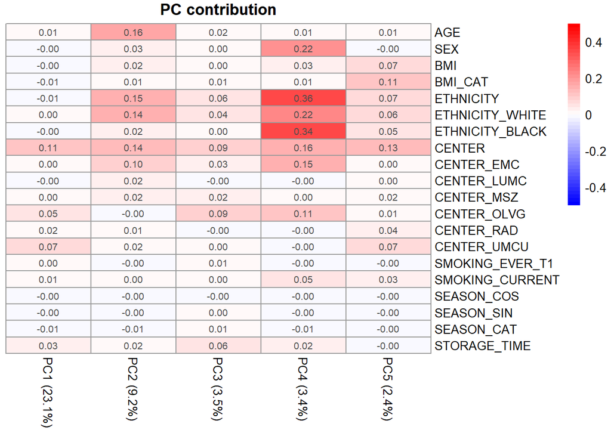

```r
merge_df <- readRDS(paste0(working_dir, "Inputs/AthenaOlink_Time_ART_Paired_Cleaned.rds"))

# select metadata with covariates
metadata <- merge_df[,c("AGE", "SEX", "BMI", "BMI_CAT", "ETHNICITY",
                         "ETHNICITY_WHITE", "ETHNICITY_BLACK",
                         "CENTER", "CENTER_EMC","CENTER_LUMC", "CENTER_MSZ",
                         "CENTER_OLVG", "CENTER_RAD", "CENTER_UMCU",
                         "SMOKING_EVER_T1", "SMOKING_CURRENT",
                         "SEASON_COS","SEASON_SIN", "SEASON_CAT",
                         "STORAGE_TIME")]

# select olink columns # GROUP3 was set as last clinical column
npx <- merge_df[,c((grep("GROUP3",colnames(merge_df))+1): grep("NFU1",colnames(merge_df)))]

# plot the PCs against selected covariates before correction
res.comp <- imputePCA(npx,ncp=5)
PCA_before_correction <- PCA(res.comp, scale.unit = T, graph = F)

plot_PCA_regression(PCA_before_correction,
                    meta_data = metadata,
                    meta_variables = c("AGE", "SEX", "BMI", "BMI_CAT", "ETHNICITY",
                                       "ETHNICITY_WHITE", "ETHNICITY_BLACK",
                                       "CENTER", "CENTER_EMC","CENTER_LUMC", "CENTER_MSZ",
                                       "CENTER_OLVG", "CENTER_RAD", "CENTER_UMCU",
                                       "SMOKING_EVER_T1", "SMOKING_CURRENT",
                                       "SEASON_COS","SEASON_SIN", "SEASON_CAT",
                                       "STORAGE_TIME"),
                    plotname = "Supplements_ECVCART_PCA_regression_uncorrected.pdf"
                    )
```

#### Define function to run PC regression on residuals

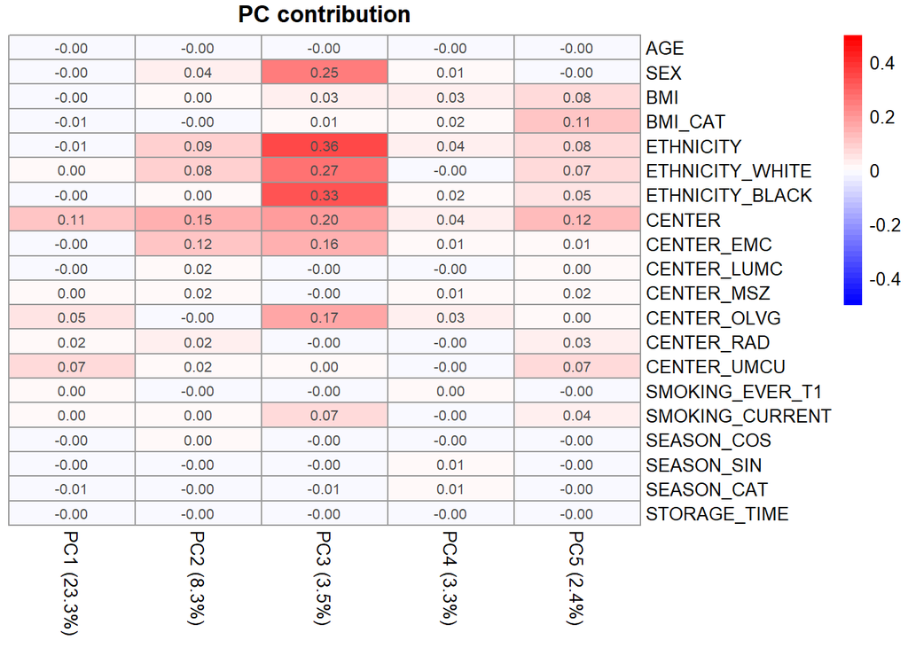

```r
library(limma)
# create function to provide PCAregression after inserting the design matrix, and plot title.
f <- function(design_cov,ti) {
# if there are NA in any of the covariates, the error will be: row dimension of design doesn't match column dimension of data object
# in this case, people with NA values should be removed, which we have done above for clinical columns using na.omit

# Generate the protein expression matrix
eset <- as.matrix(t(npx))  # Transpose data
dim(eset)
# [1] 2420  183

#Fitting model
fit1_cov <- lmFit(eset, design_cov) # limma assumes log-transformed data, which the NPX values already are

# Limma residuals matrix
ResidualsMatrix <- residuals(fit1_cov, eset)
# View(ResidualsMatrix)

dim(ResidualsMatrix)
#[1] 2420  183

# turn residuals into a data.frame in same order as metadata
Residualsdf <- data.frame(t(ResidualsMatrix))
sum(rownames(metadata) == rownames(Residualsdf)) # this should be same as the total no. of individuals

# Rerun PCA after correction
res.comp <- imputePCA(Residualsdf,ncp=5)
PCA_after_correction <-  PCA(res.comp,
                            graph = FALSE, scale.unit = TRUE)

# plot the PCs against selected covariates
plot_PCA_regression(PCA_after_correction,
                    meta_data = metadata,
                    meta_variables = c("AGE", "SEX", "BMI", "BMI_CAT", "ETHNICITY",
                                       "ETHNICITY_WHITE", "ETHNICITY_BLACK",
                                       "CENTER", "CENTER_EMC","CENTER_LUMC", "CENTER_MSZ",
                                       "CENTER_OLVG", "CENTER_RAD", "CENTER_UMCU",
                                       "SMOKING_EVER_T1", "SMOKING_CURRENT",
                                       "SEASON_COS","SEASON_SIN", "SEASON_CAT",
                                       "STORAGE_TIME"),
                    plotname = ti)
}

# See how corrections influence the data
design_AGE_STORAGETIME <- model.matrix(~AGE + STORAGE_TIME, data = merge_df)

# for sensitivity analyses
design_AGE_STORAGETIME_SEX <- model.matrix(~AGE + STORAGE_TIME + SEX, data = merge_df)
design_AGE_STORAGETIME_ETHNICITYWHITE <- model.matrix(~AGE + STORAGE_TIME + ETHNICITY_WHITE, data = merge_df) ## ethnicity has no unknown in this dataset
design_AGE_STORAGETIME_ETHNICITYBLACK <- model.matrix(~AGE + STORAGE_TIME + ETHNICITY_BLACK, data = merge_df) ## ethnicity has no unknown in this dataset
design_AGE_STORAGETIME_CENTEREMC  <- model.matrix(~AGE + STORAGE_TIME + CENTER_EMC, data = merge_df)
design_AGE_STORAGETIME_CENTEREMCMSZ  <- model.matrix(~AGE + STORAGE_TIME + CENTER_EMC + CENTER_MSZ, data = merge_df)
design_AGE_STORAGETIME_CENTEROLVG  <- model.matrix(~AGE + STORAGE_TIME + CENTER_OLVG, data = merge_df)

# Nadira's model
design_AGE_STORAGETIME_CENTER_SEX <- model.matrix(~AGE + STORAGE_TIME + CENTER + SEX, data = merge_df)

# Running the functions
f(design_AGE_STORAGETIME,"ECVCART_PCA_regression_AGE_STORAGETIME.pdf")
```

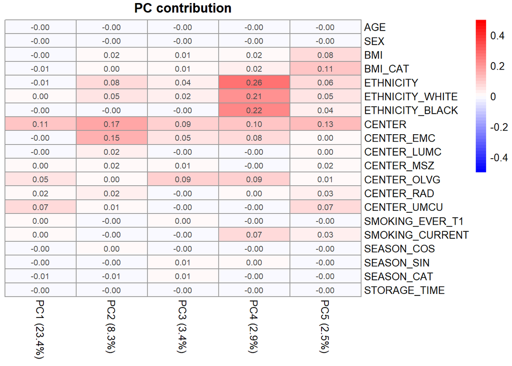

```r
# sensitivity
f(design_AGE_STORAGETIME_SEX, "Supplements_ECVCART_PCA_regression_AGE_STORAGETIME_SEX.pdf")
```

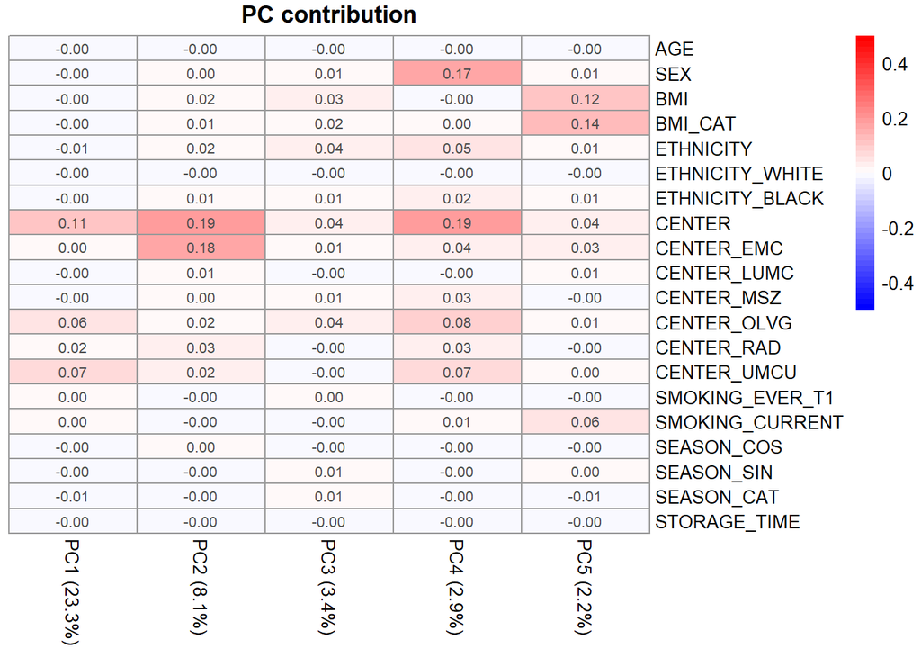

```r
f(design_AGE_STORAGETIME_ETHNICITYWHITE, "Supplements_ECVCART_PCA_regression_AGE_STORAGETIME_ETHNICITYWHITE.pdf")
```

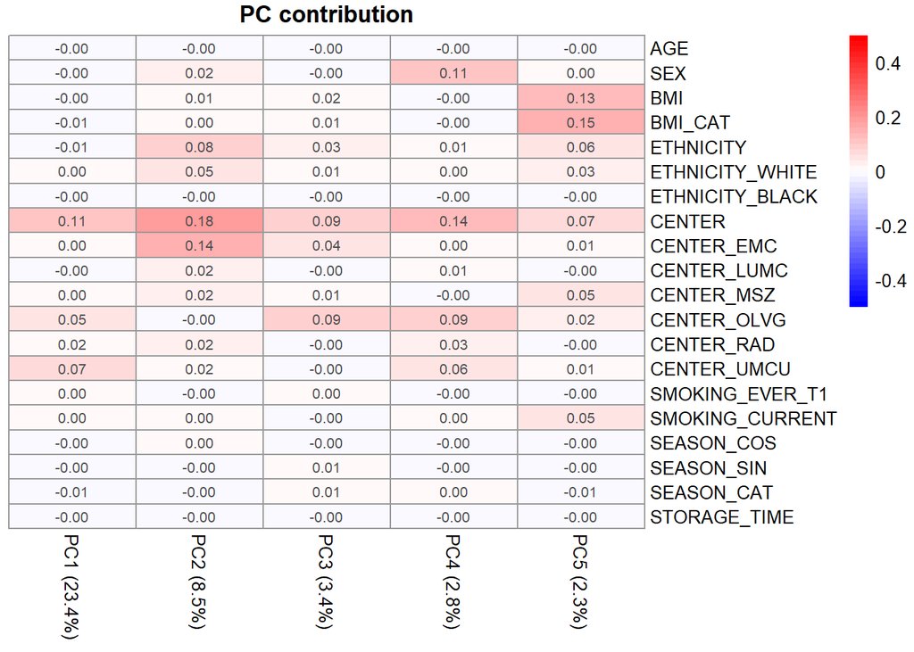

```r
f(design_AGE_STORAGETIME_ETHNICITYBLACK, "Supplements_ECVCART_PCA_regression_AGE_STORAGETIME_ETHNICITYBLACK.pdf")
```

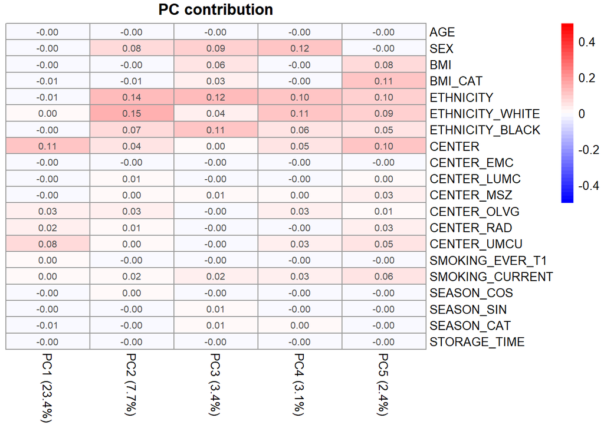

```r
f(design_AGE_STORAGETIME_CENTEREMC, "Supplements_ECVCART_PCA_regression_AGE_STORAGETIME_CENTEREMC.pdf")
```

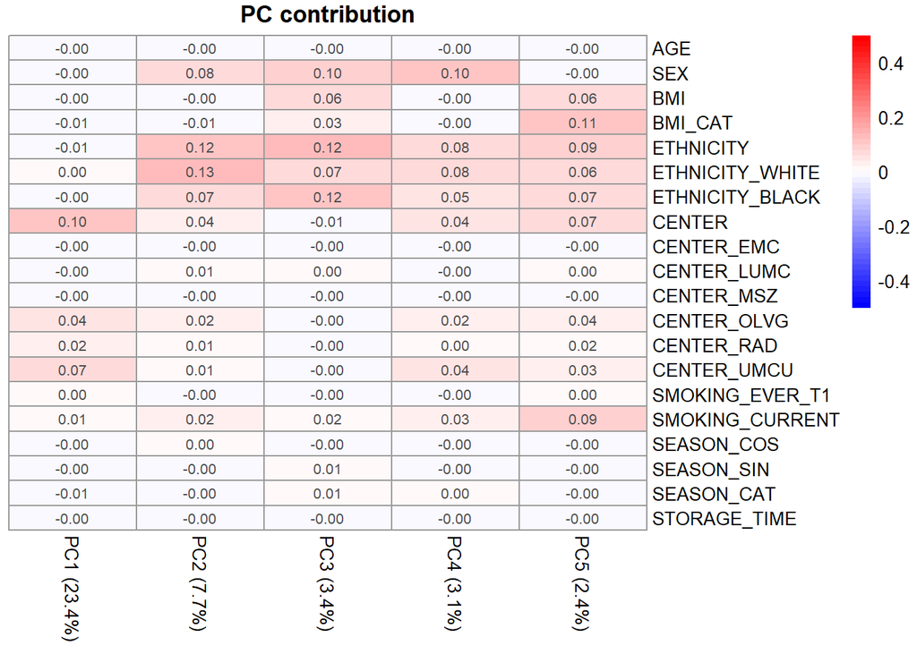

```r
f(design_AGE_STORAGETIME_CENTEREMCMSZ, "Supplements_ECVCART_PCA_regression_AGE_STORAGETIME_CENTEREMCMSZ.pdf")
```

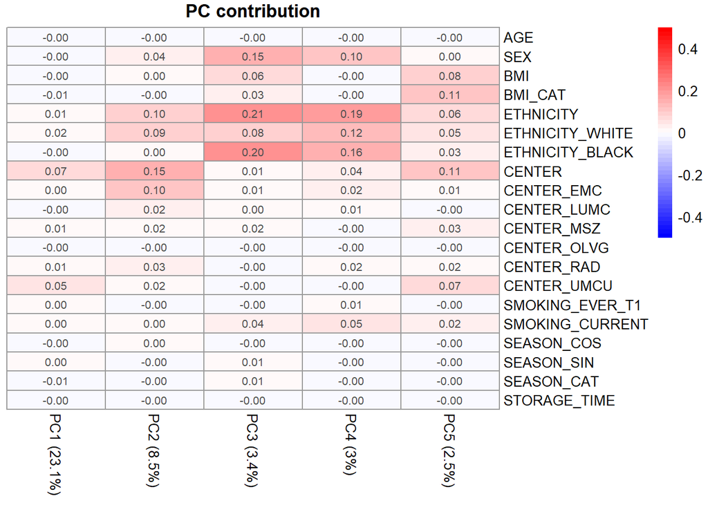

```r
f(design_AGE_STORAGETIME_CENTEROLVG, "Supplements_ECVCART_PCA_regression_AGE_STORAGETIME_CENTEROLVG.pdf")
```

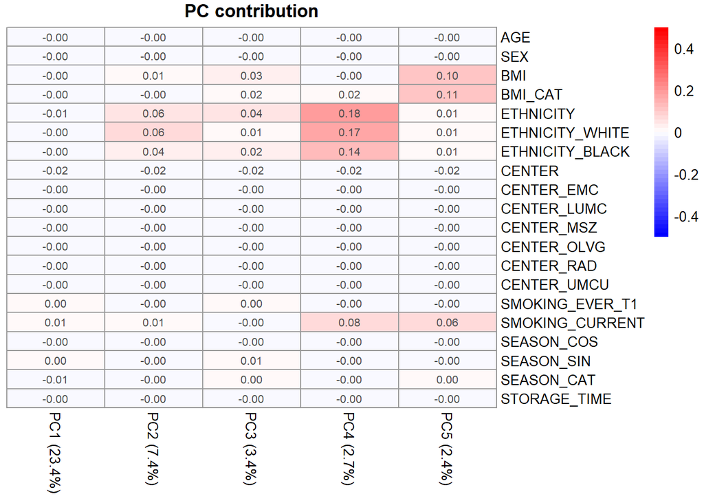

```r
# Nadira's model
f(design_AGE_STORAGETIME_CENTER_SEX, "Supplements_ECVCART_PCA_regression_AGE_STORAGETIME_CENTER_SEX.pdf")
```

#### Interpretation

The previous model with AGE, SEX, STORAGE_TIME and CENTER results in the most beautiful / cleanest PC regression. However, SEX and CENTER are unchanged between paired comparisons. If SEX and CENTER influence the results, this is either an artifact or it means that the effect of time and ART is different for sexes (could be because dosage relative to weight is usually higher for females) or center. I am not aware of a reason why ART would be more effective in each center.

Main model I believe should be corrected for AGE and STORAGE_TIME. Sensitivity analysis with additional correction for SEX and CENTER.

#### Approaches to paired analysis

1. Linear mixed models (currently in manuscript): e.g. lme() function from nlme package, as you use.
- Main difference with Limma is that the random effects are variable between pairs (SAMPLE_ID) in lme, whereas Limma assumes a fixed effect for pairs, i.e. a pseudorandom effect to account for the correlation between paired samples.
- Documentation threads online report that lme can run into problems when one batch is an outlier or if you have some further systematic differences between your batches; and limma has more statistical power. https://support.bioconductor.org/p/96097/ and https://support.bioconductor.org/p/84202/#84205 (about edgeR, but the same arguments apply to limma).
- This requires subsetting the data, limiting the maximum desired degrees of freedom.
2. LMM but as a multiple degrees of freedom (df) analysis, see below
3. Limma using full dataset as in section 9.7 ‘multilevel experiments’, page 51: https://bioconductor.org/packages/release/bioc/vignettes/limma/inst/doc/usersguide.pdf
- Join the levels in a single factor GROUP3 as above. • `design <- model.matrix(~ 0 + GROUP3 + AGE + STORAGE_TIME + SEX + CENTER, data = merge_df)` # `0+` removes the intercept • `corfit <- duplicateCorrelation(eset,design,block=targets$ID)` # estimate the correlation between measurements made on the same subject • `fit <- lmFit(eset,design,block=targets$Subject,correlation=corfit$consensus)` # this correlation is inserted in the model • `cm <- makeContrasts(EC_ART = GROUP3EC_onART - GROUP3EC_preART, VCpersistent_ART = GROUP3VCpersistent_onART - GROUP3VCpersistent_preART, VCtransient_ART = GROUP3VCtransient_onART - GROUP3VCtransient_preART, levels = design)` • `fit2 <- contrasts.fit(fit, cm)` • `fit2 <- eBayes(fit2)`
- This keeps the statistical power of the large dataset, takes into account ID as random variable and covariates.

**I tried out both 1 and 3 to see if results are consistent.**

ADDENDUM 23/2/2024:

LMM has been reported to be slightly more robust than LIMMA: https://www.ncbi.nlm.nih.gov/pmc/articles/PMC9148455/. However, in this paper, they use lmer() and contestMD() from lmerTest package for multiple degree of freedom test.

- LmerTest documentation: https://cran.r-project.org/web//packages/lmerTest/lmerTest.pdf
- Limma p 62. 3rd paragraph about moderated F statistic (Smyth) https://bioconductor.org/packages/release/bioc/vignettes/limma/inst/doc/usersguide.pdf

Lmer uses Satterthwaite’s method to calculate F statistic, where as limma calculates moderated F statistic described by Smyth.

In the paper comparing limma and LMM for multiple df testing, the FDR is slightly better in LMM, but the power is very comparable at sample size N=10. My approach with limma below is a form of multiple df testing.

*How to define the random effects?*

The random effects come from the individuals. In our previous LMM, we coded `1|ID` which shifts the intercept for a person, but not the slope. Slope random effects is not a good idea with only two timepoints, since this leads to convergence issues. A minimum of 5 levels per random effect are required: https://stats.stackexchange.com/questions/37647/what-is-the-minimum-recommended-number-of-groups-for-a-random-effects-factor/37665#37665

How to specify the random effects: https://stats.stackexchange.com/questions/31569/questions-about-how-random-effects-are-specified-in-lmer and p.7 Table 2 on https://cran.r-project.org/web/packages/lme4/vignettes/lmer.pdf

##### Approach 1: lme() from nlme package

```r
library(nlme)
# subset VCpersistent
mergedf1 <- droplevels(merge_df[which(merge_df$GROUP3 == "VCpersistent_preART" |
                                      merge_df$GROUP3 == "VCpersistent_onART"),])
olinkcolumns <- c((grep("GROUP3",colnames(merge_df))+1): grep("NFU1",colnames(merge_df)))

# run the mixed linear model regression
mod2 <- NULL
system.time(
for (i in olinkcolumns) {
  regression_formula <- as.formula(paste(names(mergedf1)[i],"~ GROUP3 + AGE + SEX + STORAGE_TIME + CENTER")) # make a formula with the olink column name
  lmod <- nlme::lme(regression_formula,
                    random = ~ 1|ID, # the IDs are set as random effect here
                    data = mergedf1,
                    na.action=na.omit,
                    control =list(msMaxIter = 1000, msMaxEval = 1000))

  # extract statistics
  stab <- t(summary(lmod)$tTable[2,]) %>% as.data.frame()
  stab$Covariate <-  "VCpersistent"
  stab$Outcome <- colnames(merge_df)[i]
  stab %>%
    dplyr::select(Outcome, Covariate, everything()) ->
    stab
  mod2 <- rbind(mod2, stab)
})
```

```
##    user  system elapsed
##   42.75    0.51   43.60
```

```r
mod2$fdr <- p.adjust(mod2$`p-value`, method = 'BH')
mod2 <- mod2[order(mod2$`p-value`),] # order by P value
mod2_sig <- mod2[mod2$fdr<0.05,]

paste("Downregulated: ",length(which(mod2_sig$Value<0)),"//",
      "Upregulated: ", length(which(mod2_sig$Value>0)))
```

```
## [1] "Downregulated:  47 // Upregulated:  0"
```

```r
# remove N=2 with unknown LOSS
mergedf2 <- merge_df[-which(is.na(merge_df$GROUP3)),]
design <- model.matrix(~ 0 + GROUP3 + AGE + STORAGE_TIME + SEX + CENTER, data = mergedf2) # N=2 with GROUP == NA are automatically removed
npx2 <- mergedf2[which(!is.na(mergedf2$GROUP3)), # remove the GROUP3 = NA, i.e. N=2 with LOSS unknown don't qualify into any subgroup.
                 c((grep("GROUP3",colnames(merge_df))+1): grep("NFU1",colnames(merge_df)))] # only Olink columns
eset2 <- as.matrix(t(npx2))
dim(eset2) # 2925  288
```

```
## [1] 2420  288
```

```r
# estimate the correlation between measurements made on the same subject
system.time(corfit <- duplicateCorrelation(eset2,design,block=mergedf2$ID))
```

```
##    user  system elapsed
##   61.47    1.22   62.94
```

```r
# fit with ID-correlation inserted
fit <- lmFit(eset2,design,block=mergedf2$ID,correlation=corfit$consensus)
cm <- makeContrasts(EC_TIME = GROUP3EC_ARTnaiveT2 - GROUP3EC_ARTnaiveT1,
                     EC_ART = GROUP3EC_onART - GROUP3EC_preART,
                     VCpersistent_TIME = GROUP3VCpersistent_ARTnaiveT2 - GROUP3VCpersistent_ARTnaiveT1,
                     VCpersistent_ART = GROUP3VCpersistent_onART - GROUP3VCpersistent_preART,
                     VCtransient_ART = GROUP3VCtransient_onART - GROUP3VCtransient_preART,
                     levels = design)
fit2 <- contrasts.fit(fit,cm)
fit2 <- eBayes(fit2)

# Display "N" number of differentially expressed proteins
example <- data.frame(NA,NA,NA,NA,NA,NA,NA)
colnames(example) <- c("logFC","AveExpr","t","P.Value","adj.P.Val","B","Outcome")
summarystatistics <- list(example,example,example,example,example)
names(summarystatistics) <-  c("EC_TIME","EC_ART","VCpersistent_TIME","VCpersistent_ART","VCtransient_ART")
for (i in  c("EC_TIME","EC_ART","VCpersistent_TIME","VCpersistent_ART","VCtransient_ART")) {
  DEP_cov <- topTable(fit2, coef = i, adjust = "BH", number = nrow(eset2)) %>%
  mutate(Outcome = rownames(.))
DEP_cov_sig <- DEP_cov[DEP_cov$P.Val<0.05,] # the FDR-significant proteins
summarystatistics[[i]] <- DEP_cov
}
summarystatistics
```

```
## $EC_TIME
##                           logFC       AveExpr             t      P.Value
## BLVRB             -0.7055691636  3.434618e-02 -3.8205976289 0.0001649015
## CA2               -1.0032466456 -4.689236e-02 -3.6638584798 0.0002984416
## PRDX2             -0.5009684834 -1.357014e-02 -3.5612061267 0.0004354400
## PKLR              -0.7461123064  5.278542e-02 -3.5324120411 0.0004833742
## CA1               -0.7532899237 -7.704410e-02 -3.4583770742 0.0006303106
## DDI2              -0.8919969516 -5.945590e-02 -3.3419373068 0.0009482331
## C9orf40           -0.9517510410 -8.967743e-02 -3.3241781032 0.0010081883
## PSMD9             -0.6852926629  1.202431e-02 -3.2881159695 0.0011409419
## CAT               -0.5562470293 -1.111111e-02 -3.2710904461 0.0012091078
## ATG4A             -0.7511555509  3.887188e-02 -3.2519481869 0.0012902561
## HBQ1              -0.6509415330 -8.956007e-02 -3.1207377274 0.0019976098
## UBAC1             -0.4040713244 -2.036701e-02 -3.0067811273 0.0028863991
## SH3GLB2           -0.6362160321  5.411111e-03 -2.9841676234 0.0031011208
## DNAJA4            -0.6724590682 -3.304792e-02 -2.9838064259 0.0031046663
## ST13              -0.7039616850  2.491597e-02 -2.9772424026 0.0031697494
## SMPD3             -0.3320501550  1.067049e-02 -2.9578796709 0.0033690857
## CCND2             -0.5014642274  2.778819e-03 -2.9270873259 0.0037098362
## AHSP              -0.9243033951 -5.781736e-02 -2.9143127903 0.0038602269
## CCS               -0.5696127492  3.184479e-02 -2.9054523500 0.0039677869
## ACYP1             -0.7720788598  2.265764e-02 -2.8877263601 0.0041912234
## NAP1L4            -0.5586428145 -1.136875e-01 -2.8530480031 0.0046618441
## HMBS              -0.4939099891 -8.819479e-02 -2.8413479750 0.0048311694
## DNAJB2            -0.6387321271  1.208333e-02 -2.8253855604 0.0050712072
## DNPH1             -0.6324472987 -3.238368e-02 -2.7996292017 0.0054814606
## BOLA2_BOLA2B      -0.6753995704 -1.917604e-02 -2.7676697344 0.0060322961
## AK1               -0.7126570982 -3.822778e-02 -2.7393657125 0.0065614859
## HDDC2             -0.3968607155  3.229722e-02 -2.7287361241 0.0067708285
## AMPD3             -0.5590278143 -1.476111e-02 -2.7157233343 0.0070353140
## TDP1              -0.7169558878  2.158788e-01 -2.7015011616 0.0073350193
## YOD1              -0.7303880040 -2.972535e-02 -2.7001517311 0.0073640459
## PSMG4             -0.5690902638  9.491319e-03 -2.6986372262 0.0073967466
## GNLY              -0.5399099472  1.123778e-01 -2.6933525689 0.0075118798
## CA3               -0.5604667719  5.569097e-02 -2.6806415911 0.0077954498
## SOD1              -0.5681184676  1.557257e-02 -2.6706175599 0.0080258387
## DNAJC9            -0.9027216792  6.488194e-02 -2.6660713450 0.0081323336
## UROD              -0.7393954806  3.114236e-03 -2.6495303960 0.0085306196
## NEDD4L            -0.4475562511 -5.910069e-03 -2.6351073277 0.0088921293
## DNAJB1            -1.0140150369  4.643160e-02 -2.6267925154 0.0091067351
```

[output cut: 24164 more lines]

```
## SERPINA5          9.862125e-01 -6.26141842          SERPINA5
## OBP2B             9.884652e-01 -6.26149172             OBP2B
## DKKL1             9.906436e-01 -6.26155615             DKKL1
## KIR3DL1           9.906436e-01 -6.26156155           KIR3DL1
## PON2              9.911335e-01 -6.26158230              PON2
## CHCHD10           9.911335e-01 -6.26158784           CHCHD10
## INSL5             9.932139e-01 -6.26163062             INSL5
## RAB6A             9.936687e-01 -6.26164330             RAB6A
## FABP4             9.937928e-01 -6.26165058             FABP4
## CAMKK1            9.947928e-01 -6.26166767            CAMKK1
## PAPPA             9.950279e-01 -6.26167450             PAPPA
## TNFRSF10B         9.956898e-01 -6.26168443         TNFRSF10B
## SFTPA2            9.957858e-01 -6.26168852            SFTPA2
## GSTA1             9.965892e-01 -6.26169671             GSTA1
## ANGPTL4           9.975640e-01 -6.26170332           ANGPTL4
```

```r
#Display number of proteins significantly expressed in two groups
results_cov <- decideTests(fit2,adjust.method = "none")
results_cov_adj <- decideTests(fit2,adjust.method = "BH")
summary(results_cov)
```

```
##        EC_TIME EC_ART VCpersistent_TIME VCpersistent_ART VCtransient_ART
## Down       180    162                27              518             746
## NotSig    2233   2239              2386             1855            1647
## Up           7     19                 7               47              27
```

```r
summary(results_cov_adj)
```

```
##        EC_TIME EC_ART VCpersistent_TIME VCpersistent_ART VCtransient_ART
## Down         0      6                 0              139             150
## NotSig    2420   2414              2420             2277            2266
## Up           0      0                 0                4               4
```

```r
grep("VAT", mod2$Outcome)
```

```
## [1] 645
```

```r
summarystatistics$VCpersistent_ART[which(summarystatistics$VCpersistent_ART$Outcome=="VAT1"),]
```

```
##          logFC     AveExpr        t      P.Value  adj.P.Val          B Outcome
## VAT1 0.2442409 -0.04155694 3.468826 0.0006073004 0.01597464 -0.6474717    VAT1
```

```r
summarystatistics$VCpersistent_ART[which(summarystatistics$VCpersistent_ART$Outcome=="LY9"),]
```

```
##          logFC    AveExpr         t      P.Value    adj.P.Val        B Outcome
## LY9 -0.5463536 0.06264132 -5.111387 6.024225e-07 8.099236e-05 5.769209     LY9
```

```r
summarystatistics$VCpersistent_ART[which(summarystatistics$VCpersistent_ART$Outcome=="CRTAM"),]
```

```
##            logFC      AveExpr         t      P.Value    adj.P.Val        B
## CRTAM -0.7822326 -0.007096528 -5.155513 4.864364e-07 6.924565e-05 5.970272
##       Outcome
## CRTAM   CRTAM
```

```r
summarystatistics$VCpersistent_ART[which(summarystatistics$VCpersistent_ART$Outcome=="CD6"),]
```

```
##         logFC  AveExpr         t      P.Value    adj.P.Val        B Outcome
## CD6 -1.668736 0.145799 -8.982891 4.459015e-17 1.079082e-13 27.97074     CD6
```

**This is probably a result of the multiple df approach in limma.**

##### Correlation between LIMMA and LMM

```r
# synchronize the two result dataframes
lmm <- mod2[,-c(2,4,5,6)]
limma <- summarystatistics$VCpersistent_ART[,-c(2,3,6)]

colnames(lmm) <- c("PROTEIN",paste0(c("LOGFC","RAW_P","FDR_P"),"_LMM"))
colnames(limma) <- c(paste0(c("LOGFC","RAW_P","FDR_P"),"_LIMMA"),"PROTEIN")
limma <- limma[,c(4,1,2,3)]

# only the proteins that are FDR significant in LIMMA
limma <- limma[which(limma$FDR_P_LIMMA <0.05 | limma$PROTEIN == "CLEC6A"),] # CLEC6A is only identified by LMM as significant

# are all LMM significant proteins also identified by LIMMA?
lmm_significant <- lmm[which(lmm$FDR_P_LMM <0.05),"PROTEIN"]
limma_significant <- limma[which(limma$FDR_P_LIMMA <0.05),"PROTEIN"]
length(which(lmm_significant %in% limma_significant))
```

```
## [1] 46
```

```r
lmm_significant[32] # "CLEC6A" # this is the one that is missing in limma_significant
```

```
## [1] "CLEC6A"
```

```r
# join together
result4 <- left_join(limma,lmm, by="PROTEIN")
head(result4)
```

```
##     PROTEIN LOGFC_LIMMA  RAW_P_LIMMA  FDR_P_LIMMA  LOGFC_LMM    RAW_P_LMM
## 1       CD6  -1.6687363 4.459015e-17 1.079082e-13 -1.4579318 8.364773e-07
## 2     ICAM3  -0.6835880 2.086617e-11 2.524806e-08 -0.6712126 4.381440e-06
## 3      CD48  -0.6087242 4.834787e-11 3.900061e-08 -0.6141019 7.292713e-07
## 4      CD80  -0.8000770 1.983455e-10 1.199990e-07 -0.8365906 4.550068e-06
## 5    SEMA7A  -0.5593408 1.012936e-09 4.441377e-07 -0.5630959 5.223205e-05
## 6 TNFRSF13B  -0.6346057 1.101168e-09 4.441377e-07 -0.6236554 5.101694e-06
##      FDR_P_LMM
## 1 0.0006747583
## 2 0.0020576832
## 3 0.0006747583
## 4 0.0020576832
## 5 0.0082896827
## 6 0.0020576832
```

```r
### make the correlation plot
# add a grouping column for coloring by significance; default value is "not significant"
result4 <- result4 %>% mutate(COLORGROUP = case_when(FDR_P_LIMMA < 0.05 & FDR_P_LMM > 0.05 & RAW_P_LMM < 0.05 ~ "Nominal with LMM",
                                               FDR_P_LIMMA < 0.05  & FDR_P_LMM < 0.05 ~ "Also FDR with LMM",
                                               FDR_P_LIMMA < 0.05 & FDR_P_LMM > 0.05 ~ "Only FDR with LIMMA",
                                               FDR_P_LIMMA > 0.05 & FDR_P_LMM < 0.05 ~ "Only FDR with LMM (n=1)"))

# add a text labels
for (i in 1:nrow(result4)){
  if(result4$FDR_P_LIMMA[i] < 0.00001 | #
     (result4$FDR_P_LMM[i] < 0.05 & result4$FDR_P_LIMMA[i] > 0.05) | # if only FDR with LMM
     (result4$PROTEIN[i] %in% c("CRTAM","LY9","CD6","VAT1")) # CRTAM, LY9, CD6, VAT1
     )
  {result4$LABEL[i] <- result4$PROTEIN[i]} else
  {result4$LABEL[i] <- ""}}

summary(as.factor(result4$COLORGROUP))
```

```
##       Also FDR with LMM        Nominal with LMM     Only FDR with LIMMA
##                      46                      86                      11
## Only FDR with LMM (n=1)
##                       1
```

```r
colnames(result4)
```

```
## [1] "PROTEIN"     "LOGFC_LIMMA" "RAW_P_LIMMA" "FDR_P_LIMMA" "LOGFC_LMM"
## [6] "RAW_P_LMM"   "FDR_P_LMM"   "COLORGROUP"  "LABEL"
```

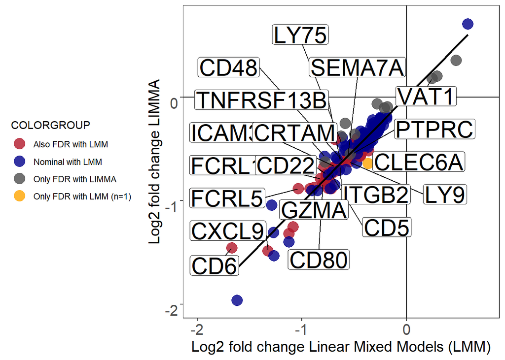

```r
# plot the data
# Create a scatter plot
options(ggrepel.max.overlaps = Inf)
ggplot(data = result4, aes(x = LOGFC_LIMMA, y = LOGFC_LMM, color = COLORGROUP)) +
  geom_point(alpha=0.8, size=5) +  # Add the dot plot
  geom_smooth(method = "lm", se = FALSE, color = "black") +  # Add the correlation line
  geom_vline(xintercept = 0) + geom_hline(yintercept = 0) +
  scale_color_manual(values = c("#b2182b","darkblue","#4d4d4d","orange")) + # "orange"
  ylim(-2, 0.75) + xlim(-2, 0.75) +
  ylab("Log2 fold change LIMMA") +
  xlab("Log2 fold change Linear Mixed Models (LMM)") +
  theme_bw() +
  theme(
        plot.title=element_text(angle=0, size=20, face="bold", vjust=1),
        panel.grid.major=element_blank(), #Remove gridlines
        panel.grid.minor=element_blank(), #Remove gridlines
        axis.text.x=element_text(angle=0, size=15, vjust=1),
        axis.text.y=element_text(angle=0, size=15, vjust=1),
        axis.title=element_text(size=15),
        legend.position = "left") +
  ggrepel::geom_label_repel(
    label.size = .25, #Size of label border, in mm.
    box.padding = unit(0.45, "lines"),
    label.padding = 0.1, # Amount of padding around label, as unit or number.
    label.r = 0.15, #Radius of rounded corners,
    size = 8,
    aes(label = LABEL, hjust = .5), color = "black")
```

```r
ggsave(paste0(working_dir, "Outputs/Supplements_ECVCART_4Q_LMMvsLIMMA_57VCPERSART_2420_age_sex_ethnicity_storage.pdf"), plot = last_plot(), device = NULL, path = NULL,scale = 1, width = 15, height =12, units = 'in', dpi = 300)
```

Excellent correlation of fold changes.

##### Sensitivity analyses

The effect of `SEX` and `CENTER` can be explored for sensitivity analyses, as well as `ETHNICITY_WHITE.` Note that there are no `ETHNICITY_WHITE == "UNKNOWN"` in this analysis.

```r
# LIMMA
design <- model.matrix(~ 0 + GROUP3 + AGE + STORAGE_TIME + SEX + CENTER, data = mergedf2) # N=2 with GROUP == NA are automatically removed

limma_ECVCART <- function(design){
  # estimate the correlation between measurements made on the same subject
  system.time(corfit <- duplicateCorrelation(eset2,design,block=mergedf2$ID))

  # fit with ID-correlation inserted
  fit <- lmFit(eset2,design,block=mergedf2$ID,correlation=corfit$consensus)
  cm <- makeContrasts(EC_TIME = GROUP3EC_ARTnaiveT2 - GROUP3EC_ARTnaiveT1,
                       EC_ART = GROUP3EC_onART - GROUP3EC_preART,
                       VCpersistent_TIME = GROUP3VCpersistent_ARTnaiveT2 - GROUP3VCpersistent_ARTnaiveT1,
                       VCpersistent_ART = GROUP3VCpersistent_onART - GROUP3VCpersistent_preART,
                       VCtransient_ART = GROUP3VCtransient_onART - GROUP3VCtransient_preART,
                       levels = design)
  fit2 <- contrasts.fit(fit,cm)
  fit2 <- eBayes(fit2)
  results_cov_adj <- decideTests(fit2,adjust.method = "BH")
  print(summary(results_cov_adj))
}

ECVCART_AGE_STORAGE <- model.matrix(~ 0 + GROUP3 + AGE + STORAGE_TIME, data = mergedf2)
ECVCART_AGE_STORAGE_SEX <- model.matrix(~ 0 + GROUP3 + AGE + STORAGE_TIME + SEX, data = mergedf2)
ECVCART_AGE_STORAGE_CENTER <- model.matrix(~ 0 + GROUP3 + AGE + STORAGE_TIME + CENTER, data = mergedf2)
ECVCART_AGE_STORAGE_SEX_CENTER <- model.matrix(~ 0 + GROUP3 + AGE + STORAGE_TIME + SEX + CENTER, data = mergedf2)

limma_ECVCART(ECVCART_AGE_STORAGE)
```

```
##        EC_TIME EC_ART VCpersistent_TIME VCpersistent_ART VCtransient_ART
## Down         0      6                 0              101              99
## NotSig    2420   2414              2420             2309            2315
## Up           0      0                 0               10               6
```

```r
limma_ECVCART(ECVCART_AGE_STORAGE_SEX)
```

```
##        EC_TIME EC_ART VCpersistent_TIME VCpersistent_ART VCtransient_ART
## Down         0      7                 0              103             110
## NotSig    2420   2413              2420             2305            2304
## Up           0      0                 0               12               6
```

```r
limma_ECVCART(ECVCART_AGE_STORAGE_CENTER)
```

```
##        EC_TIME EC_ART VCpersistent_TIME VCpersistent_ART VCtransient_ART
## Down         0      5                 0              135             129
## NotSig    2420   2415              2420             2280            2287
## Up           0      0                 0                5               4
```

```r
limma_ECVCART(ECVCART_AGE_STORAGE_SEX_CENTER)
```

```
##        EC_TIME EC_ART VCpersistent_TIME VCpersistent_ART VCtransient_ART
## Down         0      6                 0              139             150
## NotSig    2420   2414              2420             2277            2266
## Up           0      0                 0                4               4
```

```r
ECVCART_AGE_STORAGE_SEX_CENTER_ETHNICITYWHITE <- model.matrix(~ 0 + GROUP3 + AGE + STORAGE_TIME + SEX + CENTER + ETHNICITY_WHITE, data = mergedf2)
limma_ECVCART(ECVCART_AGE_STORAGE_SEX_CENTER_ETHNICITYWHITE)
```

```
##        EC_TIME EC_ART VCpersistent_TIME VCpersistent_ART VCtransient_ART
## Down         0      6                 0              142             152
## NotSig    2420   2414              2420             2272            2262
## Up           0      0                 0                6               6
```

```r
# LME
lme_ECVCART <- function(covariates){
  # run the mixed linear model regression
mod2 <- NULL
system.time(
for (i in olinkcolumns) {
  regression_formula <- as.formula(paste(names(mergedf1)[i],"~ GROUP3 +", covariates)) # make a formula with the olink column name
  lmod <- nlme::lme(regression_formula,
                    random = ~ 1|ID, # the IDs are set as random effect here
                    data = mergedf1,
                    na.action=na.omit,
                    control =list(msMaxIter = 1000, msMaxEval = 1000))

  # extract statistics
  stab <- t(summary(lmod)$tTable[2,]) %>% as.data.frame()
  stab$Covariate <-  "VCpersistent"
  stab$Outcome <- colnames(merge_df)[i]
  stab %>%
    dplyr::select(Outcome, Covariate, everything()) ->
    stab
  mod2 <- rbind(mod2, stab)
})
mod2$fdr <- p.adjust(mod2$`p-value`, method = 'BH')
mod2 <- mod2[order(mod2$`p-value`),] # order by P value
mod2_sig <- mod2[mod2$fdr<0.05,]

print(paste("Downregulated: ",length(which(mod2_sig$Value<0)),"//",
      "Upregulated: ", length(which(mod2_sig$Value>0))))
}

lme_ECVCART("AGE + STORAGE_TIME")
```

```
## [1] "Downregulated:  44 // Upregulated:  0"
```

```r
lme_ECVCART("AGE + STORAGE_TIME + SEX")
```

```
## [1] "Downregulated:  44 // Upregulated:  0"
```

```r
lme_ECVCART("AGE + STORAGE_TIME + CENTER")
```

```
## [1] "Downregulated:  46 // Upregulated:  0"
```

```r
lme_ECVCART("AGE + STORAGE_TIME + SEX + CENTER")
```

```
## [1] "Downregulated:  47 // Upregulated:  0"
```

```r
lme_ECVCART("AGE + STORAGE_TIME + ETHNICITY_WHITE")
```

```
## [1] "Downregulated:  37 // Upregulated:  0"
```

```r
lme_ECVCART("AGE + STORAGE_TIME + SEX + CENTER + ETHNICITY_WHITE")
```

```
## [1] "Downregulated:  38 // Upregulated:  0"
```

##### Run final model

Interestingly, an additional +-30 proteins (LIMMA) or 2 (LME) become FDR significant if we include CENTER. In my opinion, this could be an artefact, since the distribution of EC, VCpersistent and VCtransient is skewed across the centers and correcting for center might overestimate the effect of ART. SEX doesn’t change the results.

I prefer using Limma with AGE and STORAGE_TIME as confounders, because of: * lower degrees of freedom with limited sample size * Limma has more statistical power * we do not have clear indications that we need linear mixed model * SEX and CENTER are unchanged within pairs, and correcting for SEX doesn’t matter and for CENTER introduces an unexpected increase in FDR-significant proteins, that is difficult to interpret.

Discussed with Nadira, and the preference is for VC to correct for SEX and CENTER as well, to avoid any imbalances between the pairs. For EC, sample size does not allow for it.

Preference is to use LME, because it is more conventional and we can be sure about the proteins that are FDR significant.

```r
example <- data.frame(NA,NA,NA,NA,NA,NA,NA,NA)
colnames(example) <- c("Outcome","Covariate","Value","Std.Error","DF","t-value","p-value","fdr")
summarystatistics <- list(example,example,example,example,example)
names(summarystatistics) <-  c("EC_TIME","EC_ART","VCpersistent_TIME","VCpersistent_ART","VCtransient_ART")

lmm_on_subset <- function(analysisname, treatment, reference, covar_text) {
mergedf1 <- droplevels(merge_df[which(merge_df$GROUP3 == treatment|
                                      merge_df$GROUP3 == reference),])
olinkcolumns <- c((grep("GROUP3",colnames(merge_df))+1): grep("NFU1",colnames(merge_df)))

# run the mixed linear model regression
mod2 <- NULL
system.time(
for (i in olinkcolumns) {
  regression_formula <- as.formula(paste(names(mergedf1)[i],"~ GROUP3 +",covar_text)) # make a formula with the olink column name
  lmod <- nlme::lme(regression_formula,
                    random = ~ 1|ID, # the IDs are set as random effect here
                    data = mergedf1,
                    na.action=na.omit,
                    control =list(msMaxIter = 1000, msMaxEval = 1000))

  # extract statistics
  stab <- t(summary(lmod)$tTable[2,]) %>% as.data.frame()
  stab$Covariate <-  analysisname
  stab$Outcome <- colnames(merge_df)[i]
  stab %>%
    dplyr::select(Outcome, Covariate, everything()) ->
    stab
  mod2 <- rbind(mod2, stab)
})
mod2$fdr <- p.adjust(mod2$`p-value`, method = 'BH')
mod2 <- mod2[order(mod2$`p-value`),] # order by P value

return (mod2)
}

summarystatistics[["EC_TIME"]] <- lmm_on_subset("EC_TIME", "EC_ARTnaiveT2", "EC_ARTnaiveT1", "AGE + STORAGE_TIME")
summarystatistics[["EC_ART"]] <- lmm_on_subset("EC_ART", "EC_onART", "EC_preART", "AGE + STORAGE_TIME")
summarystatistics[["VCpersistent_TIME"]] <- lmm_on_subset("VCpersistent_TIME", "VCpersistent_ARTnaiveT2", "VCpersistent_ARTnaiveT1", "AGE + SEX + STORAGE_TIME + CENTER")
summarystatistics[["VCpersistent_ART"]] <- lmm_on_subset("VCpersistent_ART", "VCpersistent_onART", "VCpersistent_preART", "AGE + SEX + STORAGE_TIME + CENTER")
summarystatistics[["VCtransient_ART"]] <- lmm_on_subset("VCtransient_ART", "VCtransient_onART", "VCtransient_preART", "AGE + SEX + STORAGE_TIME + CENTER")

summarystatistics
```

```
## $EC_TIME
##                Outcome Covariate         Value  Std.Error DF       t-value
## 2221            VCPKMT   EC_TIME -1.6960339027 0.39480602 16 -4.2958664013
## 1326              GNLY   EC_TIME -1.7987276801 0.53666316 16 -3.3516883792
## 255              FUCA1   EC_TIME -0.7623432126 0.24511408 16 -3.1101567141
## 2310            DUSP13   EC_TIME -0.7980984379 0.25713609 16 -3.1037978168
## 1187              VWC2   EC_TIME  0.6011088527 0.20771203 16  2.8939529404
## 1694           S100A13   EC_TIME -0.6850599925 0.23917464 16 -2.8642668051
## 116               CTSL   EC_TIME -0.4891527451 0.17124566 16 -2.8564387576
## 2295             PCSK7   EC_TIME  0.5697900307 0.20333826 16  2.8021781979
## 239              MFAP5   EC_TIME  0.7110371849 0.26179958 16  2.7159599633
## 1854             MFAP4   EC_TIME  0.4477961931 0.16696810 16  2.6819265517
## 703               RRM2   EC_TIME -0.9935430751 0.37079196 16 -2.6795162259
## 1179            ADAM22   EC_TIME  0.6410123672 0.23973477 16  2.6738397941
## 770              CDC27   EC_TIME -1.3168323086 0.49311767 16 -2.6704220668
```

[output cut: 24204 more lines]

```r
# change list names so it includes sample size:
names(summarystatistics) <- paste0(names(summarystatistics),"_",c("19","9","23","57","36"))
# c("EC_TIME_19","EC_ART_9","VCpersistent_TIME_23","VCpersistent_ART_57","VCtransient_ART_36")

openxlsx::write.xlsx(summarystatistics,paste0(working_dir,"Outputs/Supplements_LMM_Olink_ECVC_ARTandTIME_2420_age_storage_sex_center.xlsx"))
```

Also with LIMMA for completeness of script. We may come back to it later.

```r
# remove the N=2 with GROUP == NA again
mergedf2 <- merge_df[-which(is.na(merge_df$GROUP3)),]
# Create model design formula
design <- model.matrix(~ 0 + GROUP3 + AGE + STORAGE_TIME + SEX + CENTER, data = mergedf2) # N=2 with GROUP == NA are automatically removed
npx2 <- mergedf2[which(!is.na(mergedf2$GROUP3)), # remove the GROUP3 = NA, i.e. N=2 with LOSS unknown don't qualify into any subgroup.
                 c((grep("GROUP3",colnames(merge_df))+1): grep("NFU1",colnames(merge_df)))] # only Olink columns
eset2 <- as.matrix(t(npx2))
dim(eset2) # 2925  288
```

```
## [1] 2420  288
```

```r
# estimate the correlation between measurements made on the same subject
system.time(corfit <- duplicateCorrelation(eset2,design,block=mergedf2$ID))
```

```
##    user  system elapsed
##   55.65    0.16   55.83
```

```r
# fit with ID-correlation inserted
fit <- lmFit(eset2,design,block=mergedf2$ID,correlation=corfit$consensus)
cm <- makeContrasts(EC_TIME = GROUP3EC_ARTnaiveT2 - GROUP3EC_ARTnaiveT1,
                     EC_ART = GROUP3EC_onART - GROUP3EC_preART,
                     VCpersistent_TIME = GROUP3VCpersistent_ARTnaiveT2 - GROUP3VCpersistent_ARTnaiveT1,
                     VCpersistent_ART = GROUP3VCpersistent_onART - GROUP3VCpersistent_preART,
                     VCtransient_ART = GROUP3VCtransient_onART - GROUP3VCtransient_preART,
                     levels = design)
fit2 <- contrasts.fit(fit,cm)
fit2 <- eBayes(fit2)

# Display "N" number of differentially expressed proteins
example <- data.frame(NA,NA,NA,NA,NA,NA,NA)
colnames(example) <- c("logFC","AveExpr","t","P.Value","adj.P.Val","B","Outcome")
summarystatistics <- list(example,example,example,example,example)
names(summarystatistics) <-  c("EC_TIME","EC_ART","VCpersistent_TIME","VCpersistent_ART","VCtransient_ART")
for (i in  c("EC_TIME","EC_ART","VCpersistent_TIME","VCpersistent_ART","VCtransient_ART")) {
  DEP_cov <- topTable(fit2, coef = i, adjust = "BH", number = nrow(eset2)) %>%
  mutate(Outcome = rownames(.))
DEP_cov_sig <- DEP_cov[DEP_cov$P.Val<0.05,] # the FDR-significant proteins
summarystatistics[[i]] <- DEP_cov
}
summarystatistics
```

```
## $EC_TIME
##                           logFC       AveExpr             t      P.Value
## BLVRB             -0.7055691636  3.434618e-02 -3.8205976289 0.0001649015
## CA2               -1.0032466456 -4.689236e-02 -3.6638584798 0.0002984416
## PRDX2             -0.5009684834 -1.357014e-02 -3.5612061267 0.0004354400
## PKLR              -0.7461123064  5.278542e-02 -3.5324120411 0.0004833742
## CA1               -0.7532899237 -7.704410e-02 -3.4583770742 0.0006303106
## DDI2              -0.8919969516 -5.945590e-02 -3.3419373068 0.0009482331
## C9orf40           -0.9517510410 -8.967743e-02 -3.3241781032 0.0010081883
## PSMD9             -0.6852926629  1.202431e-02 -3.2881159695 0.0011409419
## CAT               -0.5562470293 -1.111111e-02 -3.2710904461 0.0012091078
## ATG4A             -0.7511555509  3.887188e-02 -3.2519481869 0.0012902561
## HBQ1              -0.6509415330 -8.956007e-02 -3.1207377274 0.0019976098
## UBAC1             -0.4040713244 -2.036701e-02 -3.0067811273 0.0028863991
## SH3GLB2           -0.6362160321  5.411111e-03 -2.9841676234 0.0031011208
## DNAJA4            -0.6724590682 -3.304792e-02 -2.9838064259 0.0031046663
## ST13              -0.7039616850  2.491597e-02 -2.9772424026 0.0031697494
## SMPD3             -0.3320501550  1.067049e-02 -2.9578796709 0.0033690857
## CCND2             -0.5014642274  2.778819e-03 -2.9270873259 0.0037098362
## AHSP              -0.9243033951 -5.781736e-02 -2.9143127903 0.0038602269
## CCS               -0.5696127492  3.184479e-02 -2.9054523500 0.0039677869
## ACYP1             -0.7720788598  2.265764e-02 -2.8877263601 0.0041912234
## NAP1L4            -0.5586428145 -1.136875e-01 -2.8530480031 0.0046618441
## HMBS              -0.4939099891 -8.819479e-02 -2.8413479750 0.0048311694
## DNAJB2            -0.6387321271  1.208333e-02 -2.8253855604 0.0050712072
## DNPH1             -0.6324472987 -3.238368e-02 -2.7996292017 0.0054814606
## BOLA2_BOLA2B      -0.6753995704 -1.917604e-02 -2.7676697344 0.0060322961
## AK1               -0.7126570982 -3.822778e-02 -2.7393657125 0.0065614859
## HDDC2             -0.3968607155  3.229722e-02 -2.7287361241 0.0067708285
## AMPD3             -0.5590278143 -1.476111e-02 -2.7157233343 0.0070353140
## TDP1              -0.7169558878  2.158788e-01 -2.7015011616 0.0073350193
## YOD1              -0.7303880040 -2.972535e-02 -2.7001517311 0.0073640459
## PSMG4             -0.5690902638  9.491319e-03 -2.6986372262 0.0073967466
## GNLY              -0.5399099472  1.123778e-01 -2.6933525689 0.0075118798
## CA3               -0.5604667719  5.569097e-02 -2.6806415911 0.0077954498
## SOD1              -0.5681184676  1.557257e-02 -2.6706175599 0.0080258387
## DNAJC9            -0.9027216792  6.488194e-02 -2.6660713450 0.0081323336
## UROD              -0.7393954806  3.114236e-03 -2.6495303960 0.0085306196
## NEDD4L            -0.4475562511 -5.910069e-03 -2.6351073277 0.0088921293
## DNAJB1            -1.0140150369  4.643160e-02 -2.6267925154 0.0091067351
```

[output cut: 24164 more lines]

```
## SERPINA5          9.862125e-01 -6.26141842          SERPINA5
## OBP2B             9.884652e-01 -6.26149172             OBP2B
## DKKL1             9.906436e-01 -6.26155615             DKKL1
## KIR3DL1           9.906436e-01 -6.26156155           KIR3DL1
## PON2              9.911335e-01 -6.26158230              PON2
## CHCHD10           9.911335e-01 -6.26158784           CHCHD10
## INSL5             9.932139e-01 -6.26163062             INSL5
## RAB6A             9.936687e-01 -6.26164330             RAB6A
## FABP4             9.937928e-01 -6.26165058             FABP4
## CAMKK1            9.947928e-01 -6.26166767            CAMKK1
## PAPPA             9.950279e-01 -6.26167450             PAPPA
## TNFRSF10B         9.956898e-01 -6.26168443         TNFRSF10B
## SFTPA2            9.957858e-01 -6.26168852            SFTPA2
## GSTA1             9.965892e-01 -6.26169671             GSTA1
## ANGPTL4           9.975640e-01 -6.26170332           ANGPTL4
```

```r
# change list names so it includes sample size:
names(summarystatistics) <- paste0(names(summarystatistics),"_",c("19","9","23","57","36"))
# c("EC_TIME_19","EC_ART_9","VCpersistent_TIME_23","VCpersistent_ART_57","VCtransient_ART_36")

# write the summary statistics to excel table, with each comparison on a different sheet.
openxlsx::write.xlsx(summarystatistics,paste0(working_dir,"Outputs/Supplements_LIMMA_Olink_ECVC_ARTandTIME_2420_age_storage_sex_center.xlsx"))
```

#### Figure 2A - volcano VCpersistent

```r
# read the summary statistics for VC persistent
result2 <- openxlsx::read.xlsx(paste0(working_dir, "Outputs/Supplements_LMM_Olink_ECVC_ARTandTIME_2420_age_storage_sex_center.xlsx"), sheet = "VCpersistent_ART_57")

diff_df <- result2[,c("Outcome","p-value","fdr","Value")]
colnames(diff_df) <- c("PROTEIN","RAW_P", "FDR_P","LOG_FC")

# add a grouping column for coloring by significance; default value is "not significant"
diff_df <- diff_df %>% mutate(group= case_when(FDR_P < 0.05 ~ "FDR Significant",
                                               RAW_P < 0.05 & FDR_P > 0.05 ~ "Nominal Significant",
                                               RAW_P > 0.05 ~ "NotSignificant"
                                               ))

# add a text label if 'FDR-P <0.01', or if 'FDR-P <0.05 but LOG_FC >2', or if CRTAM, LY9, CD6, VAT1.
for (i in 1:nrow(diff_df)){
  if(diff_df$FDR_P[i] < 0.01 | # 'FDR-P <0.01'
     (diff_df$FDR_P[i] < 0.05 & abs(diff_df$LOG_FC[i]) > 2 | # 'FDR-P <0.05 but LOG_FC >2'
     (diff_df$PROTEIN[i] %in% c("CRTAM","LY9","CD6","VAT1") # CRTAM, LY9, CD6, VAT1
     )))
  {diff_df$LABEL[i] <- diff_df$PROTEIN[i]} else
  {diff_df$LABEL[i] <- ""}}
diff_df
```

```
##                PROTEIN        RAW_P        FDR_P        LOG_FC
## 1                 CD48 7.292713e-07 0.0006747583 -0.6141018577
## 2                PTPRC 8.007569e-07 0.0006747583 -0.5455029495
## 3                  CD6 8.364773e-07 0.0006747583 -1.4579317820
## 4                ICAM3 4.381440e-06 0.0020576832 -0.6712126113
## 5                 CD80 4.550068e-06 0.0020576832 -0.8365906303
## 6            TNFRSF13B 5.101694e-06 0.0020576832 -0.6236553686
## 7                  LY9 1.322546e-05 0.0045722296 -0.6255845305
## 8                CXCL9 1.774083e-05 0.0053666013 -1.4851894329
## 9               CXCL10 2.417707e-05 0.0065009455 -1.2541936437
## 10               FCRL1 3.358240e-05 0.0081269412 -0.7885260362
## 11             TNFRSF8 4.301858e-05 0.0082373737 -0.8851606903
## 12                ADA2 4.379003e-05 0.0082373737 -0.7132763161
## 13                 CD5 4.425035e-05 0.0082373737 -0.7465932422
## 14               FCRL2 5.161015e-05 0.0082896827 -0.6814807257
```

[output cut: 4827 more lines]

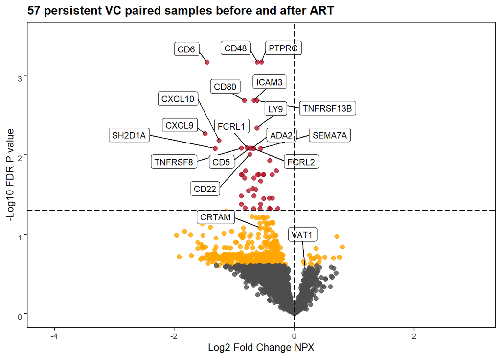

```r
# make the volcano plot
options(ggrepel.max.overlaps = Inf)
g <- ggplot(diff_df, aes(x=LOG_FC, y=-log10(FDR_P))) +
  geom_point(aes(color=group), alpha=0.8, size=2) +
  scale_color_manual(values=c("#b2182b","orange","#4d4d4d")) +
  theme_bw() + # size of plotting window
  theme(legend.background=element_rect(),
        plot.title=element_text(angle=0, size=12, face="bold", vjust=1),
        panel.grid.major=element_blank(), #Remove gridlines
        panel.grid.minor=element_blank(), #Remove gridlines
        axis.text.x=element_text(angle=0, size=8, vjust=1),
        axis.text.y=element_text(angle=0, size=8, vjust=1),
        axis.title=element_text(size=10),
        legend.position = "none") +
  # guides(colour = guide_legend(override.aes=list(size=2.5))) + #  Change the size of the icons/symbols in the legend
  xlab("Log2 Fold Change NPX") +
  ylab("-Log10 FDR P value") +
  ggtitle("57 persistent VC paired samples before and after ART" ) +
  geom_label_repel(  #Add the text labels
    label.size = .25, #Size of label border, in mm.
    box.padding = unit(0.45, "lines"),
    label.padding = 0.25, # Amount of padding around label, as unit or number.
    label.r = 0.15, #Radius of rounded corners,
    size = 3, aes(label = LABEL,hjust = .5))+
  xlim(-4.1,3) + ylim(0,3.5) + # limits of the graph
  geom_vline(xintercept=c(0), linetype="longdash", colour="black", size=0.4) + # Add a vertical line for Estimate change cut-offs
  geom_hline(yintercept=-log10(0.05), linetype="longdash", colour="black", size=0.4) #Add a horizontal line for P-value cut-off
g
```

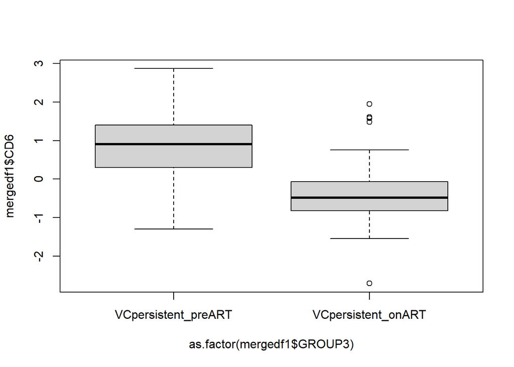

```r
ggsave(paste0(working_dir, "Outputs/ECVCART_Volcano_label_0.01FDRP_2FC_57VCpersistent_ART_2420_age_storage.pdf"), plot = g, device = NULL, path = NULL, width = 4, height =4, units = 'in', dpi = 300)

# Check direction:
mergedf1 <- droplevels(merge_df[which(merge_df$GROUP3 == "VCpersistent_preART" |
                                      merge_df$GROUP3 == "VCpersistent_onART"),])
boxplot(mergedf1$CD6~as.factor(mergedf1$GROUP3))
```

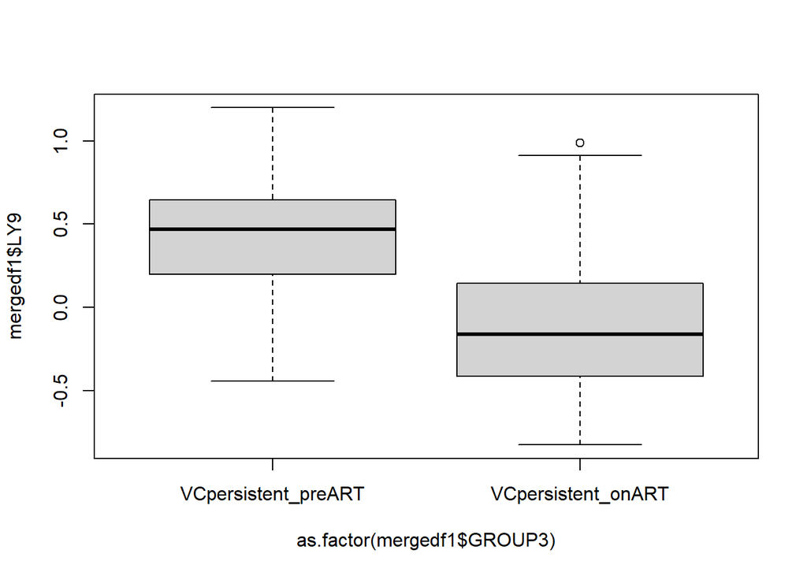

```r
boxplot(mergedf1$LY9~as.factor(mergedf1$GROUP3))
```

#### Figure 2B - 4quadrant VCpersistent ART & TIME

```r
# read the summary statistics for VC persistent
result_art <- openxlsx::read.xlsx(paste0(working_dir, "Outputs/Supplements_LMM_Olink_ECVC_ARTandTIME_2420_age_storage_sex_center.xlsx"), sheet = "VCpersistent_ART_57")
result_art <- result_art[,c("Outcome","p-value","fdr","Value")]
colnames(result_art) <- c("PROTEIN","RAW_P_ART", "FDR_P_ART","LOG_FC_ART")

# read the summary statistics for VC persistent over TIME
result_time <- openxlsx::read.xlsx(paste0(working_dir, "Outputs/Supplements_LMM_Olink_ECVC_ARTandTIME_2420_age_storage_sex_center.xlsx"), sheet = "VCpersistent_TIME_23")
result_time <- result_time[,c("Outcome","p-value","fdr","Value")]
colnames(result_time) <- c("PROTEIN","RAW_P_TIME", "FDR_P_TIME","LOG_FC_TIME")

# combine the two
result3 <- merge(result_art, result_time, by = "PROTEIN")
result3 <- result3[order(result3$RAW_P_ART),]

# add a grouping column for coloring by significance; default value is "not significant"
result3 <- result3 %>% mutate(COLORGROUP = case_when(FDR_P_ART < 0.05 & ((RAW_P_TIME > 0.05) | ((LOG_FC_ART > 0) != (LOG_FC_TIME > 0))) ~ "Effect_of_ART",
                                               RAW_P_TIME < 0.05 & (LOG_FC_ART > 0) == (LOG_FC_TIME > 0)~ "Influenced_by_time",
                                               RAW_P_TIME > 0.05 | FDR_P_ART > 0.05 ~ "NotSignificant"
                                               ))

# remove non-significant proteins over ART
result3 <- result3[-which(result3$FDR_P_ART > 0.05 & result3$PROTEIN != "CRTAM"),]

# add a text labels
for (i in 1:nrow(result3)){
  if(result3$FDR_P_ART[i] < 0.01 | #
     (result3$RAW_P_TIME[i] < 0.05) | # add label if raw P significant over time
     (result3$FDR_P_ART[i] < 0.05 & abs(result3$LOG_FC_ART[i]) > 2 | #
     (result3$PROTEIN[i] %in% c("CRTAM","LY9","CD6","VAT1") # CRTAM, LY9, CD6, VAT1
     )))
  {result3$LABEL[i] <- result3$PROTEIN[i]} else
  {result3$LABEL[i] <- ""}}

levels(as.factor(result3$COLORGROUP))
```

```
## [1] "Effect_of_ART"  "NotSignificant"
```

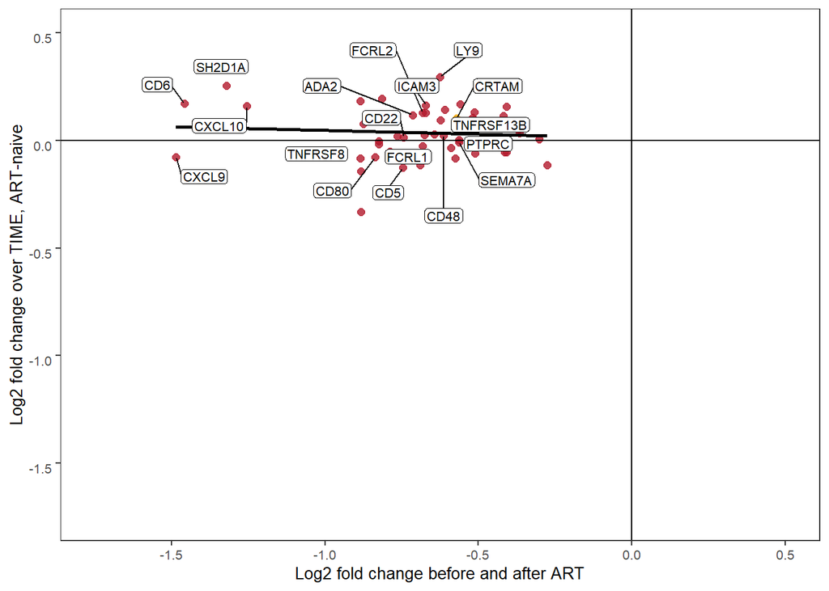

```r
# plot the data
# Create a scatter plot
options(ggrepel.max.overlaps = Inf)
ggplot(data = result3, aes(x = LOG_FC_ART, y = LOG_FC_TIME, color = COLORGROUP)) +
  geom_point(alpha=0.8, size=2) +  # Add the dot plot
  geom_smooth(method = "lm", se = FALSE, color = "black") +  # Add the correlation line
  geom_vline(xintercept = 0) + geom_hline(yintercept = 0) +
  scale_color_manual(values = c("#b2182b","orange"), name = "") + # "orange"
  ylim(-1.75, 0.5) + xlim(-1.75, 0.5) +
  ylab("Log2 fold change over TIME, ART-naive") +
  xlab("Log2 fold change before and after ART") +
  theme_bw() +
  theme(legend.background=element_rect(),
        plot.title=element_text(angle=0, size=12, face="bold", vjust=1),
        panel.grid.major=element_blank(), #Remove gridlines
        panel.grid.minor=element_blank(), #Remove gridlines
        axis.text.x=element_text(angle=0, size=8, vjust=1),
        axis.text.y=element_text(angle=0, size=8, vjust=1),
        axis.title=element_text(size=10),
        legend.position = "none") +
  ggrepel::geom_label_repel(
    label.size = .25, #Size of label border, in mm.
    box.padding = unit(0.45, "lines"),
    label.padding = 0.1, # Amount of padding around label, as unit or number.
    label.r = 0.15, #Radius of rounded corners,
    size = 2.75,
    aes(label = LABEL, hjust = .5), color = "black")
```

```r
ggsave(paste0(working_dir, "Outputs/ECVCART_4Q_label_0.001FDRPART_2FC_0.05RAWPTIME_57VCPERSART_23VCPERSTIME_2420_age_storage.pdf"), plot = last_plot(), device = NULL, path = NULL,scale = 1, width = 3.5, height = 3, units = 'in', dpi = 300)
```

#### Figure 2C - volcano VCtransient

```r
# read the summary statistics for VC persistent
result2 <- openxlsx::read.xlsx(paste0(working_dir, "Outputs/Supplements_LMM_Olink_ECVC_ARTandTIME_2420_age_storage_sex_center.xlsx"), sheet = "VCtransient_ART_36")

diff_df <- result2[,c("Outcome","p-value","fdr","Value")]
colnames(diff_df) <- c("PROTEIN","RAW_P", "FDR_P","LOG_FC")

# add a grouping column for coloring by significance; default value is "not significant"
diff_df <- diff_df %>% mutate(group= case_when(FDR_P < 0.05 ~ "FDR Significant",
                                               RAW_P < 0.05 & FDR_P > 0.05 ~ "Nominal Significant",
                                               RAW_P > 0.05 ~ "NotSignificant"
                                               ))

# add a text label if 'FDR-P <0.05', or if 'FDR-P <0.05 but LOG_FC >2', or if CRTAM, LY9, CD6, VAT1.
for (i in 1:nrow(diff_df)){
  if(diff_df$RAW_P[i] < 0.001 | # 'FDR-P <0.05'
     (diff_df$FDR_P[i] < 0.05 & abs(diff_df$LOG_FC[i]) > 2 | # 'FDR-P <0.05 but LOG_FC >2'
     (diff_df$PROTEIN[i] %in% c("CRTAM","LY9","CD6","VAT1") # CRTAM, LY9, CD6, VAT1
     )))
  {diff_df$LABEL[i] <- diff_df$PROTEIN[i]} else
  {diff_df$LABEL[i] <- ""}}
diff_df
```

```
##                PROTEIN        RAW_P      FDR_P        LOG_FC
## 1                FCRL5 4.944189e-06 0.01196494 -2.2168956908
## 2             TNFRSF17 1.675208e-05 0.02027002 -1.3604589346
## 3                 CD48 5.617969e-05 0.04531828 -1.0326642886
## 4                CASP4 9.380090e-05 0.04698183 -4.0196872555
## 5                 OTOA 9.706990e-05 0.04698183 -2.1439640183
## 6            TNFRSF13B 1.801732e-04 0.06260258 -1.1533015685
## 7                ITGB2 1.810818e-04 0.06260258 -0.7756433032
## 8                ICAM3 2.309784e-04 0.06987096 -1.0501142449
## 9               SLAMF7 3.031176e-04 0.08150495 -1.2609856408
## 10                 CD6 3.395926e-04 0.08218141 -1.8623534947
## 11              JCHAIN 3.850270e-04 0.08470595 -1.4709291794
## 12               FCRL1 5.551317e-04 0.09862596 -1.5844826910
## 13            SERPINI1 5.885770e-04 0.09862596 -0.5887775271
## 14                CD5L 5.933503e-04 0.09862596 -0.9796270225
```

[output cut: 4827 more lines]

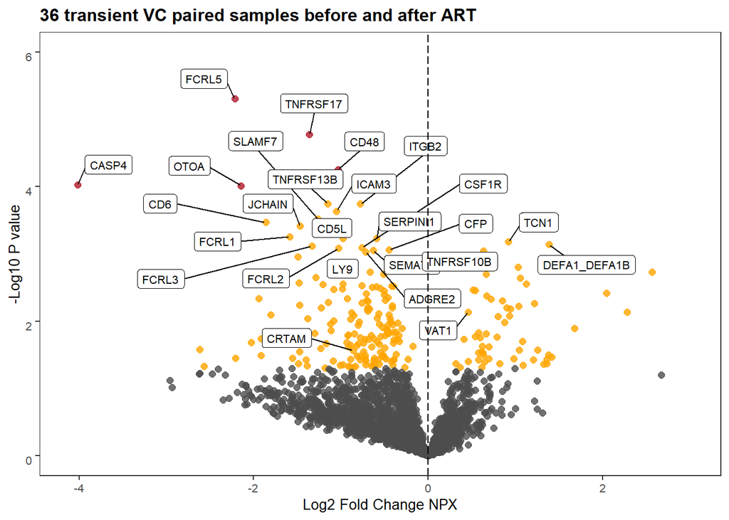

```r
# make the volcano plot
options(ggrepel.max.overlaps = Inf)
g <- ggplot(diff_df, aes(x=LOG_FC, y=-log10(RAW_P))) +
  geom_point(aes(color=group), alpha=0.8, size=2) +
  scale_color_manual(values=c("#b2182b","orange","#4d4d4d")) +
  theme_bw() + # size of plotting window
  theme(legend.background=element_rect(),
        plot.title=element_text(angle=0, size=12, face="bold", vjust=1),
        panel.grid.major=element_blank(), #Remove gridlines
        panel.grid.minor=element_blank(), #Remove gridlines
        axis.text.x=element_text(angle=0, size=8, vjust=1),
        axis.text.y=element_text(angle=0, size=8, vjust=1),
        axis.title=element_text(size=10),
        legend.position = "none") +
  # guides(colour = guide_legend(override.aes=list(size=2.5))) + #  Change the size of the icons/symbols in the legend
  xlab("Log2 Fold Change NPX") +
  ylab("-Log10 P value") +
  ggtitle("36 transient VC paired samples before and after ART" ) +
  geom_label_repel(  #Add the text labels
    label.size = .25, #Size of label border, in mm.
    box.padding = unit(0.45, "lines"),
    label.padding = 0.25, # Amount of padding around label, as unit or number.
    label.r = 0.15, #Radius of rounded corners,
    size = 2.75, aes(label = LABEL,hjust = .5))+
  xlim(-4.1,3) + ylim(0, 6) + # limits of the graph
  geom_vline(xintercept=c(0), linetype="longdash", colour="black", size=0.4) + # Add a vertical line for Estimate change cut-offs
  geom_hline(yintercept= log10(0.05), linetype="longdash", colour="black", size=0.4) #Add a horizontal line for P-value cut-off
g
```

```r
ggsave(paste0(working_dir, "Outputs/ECVCART_Volcano_label_0.001FDRP_2FC_36VCtransient_ART_2420_age_storage.pdf"), plot = g, width = 4, height =4, units = 'in', dpi = 300)
```

#### Figure 2D - volcano ECpersistent

```r
# read the summary statistics for VC persistent
result2 <- openxlsx::read.xlsx(paste0(working_dir, "Outputs/Supplements_LMM_Olink_ECVC_ARTandTIME_2420_age_storage_sex_center.xlsx"), sheet = "EC_ART_9")

diff_df <- result2[,c("Outcome","p-value","fdr","Value")]
colnames(diff_df) <- c("PROTEIN","RAW_P", "FDR_P","LOG_FC")

# add a grouping column for coloring by significance; default value is "not significant"
diff_df <- diff_df %>% mutate(group= case_when(FDR_P < 0.05 ~ "FDR Significant",
                                               RAW_P < 0.05 & FDR_P > 0.05 ~ "Nominal Significant",
                                               RAW_P > 0.05 ~ "NotSignificant"
                                               ))

# add a text label if 'FDR-P <0.05', or if 'FDR-P <0.05 but LOG_FC >2', or if CRTAM, LY9, CD6, VAT1.
for (i in 1:nrow(diff_df)){
  if(diff_df$RAW_P[i] < 0.01 | # 'FDR-P <0.05'
     (diff_df$FDR_P[i] < 0.05 & abs(diff_df$LOG_FC[i]) > 2 | # 'FDR-P <0.05 but LOG_FC >2'
     (diff_df$PROTEIN[i] %in% c("CRTAM","LY9","CD6","VAT1") # CRTAM, LY9, CD6, VAT1
     )))
  {diff_df$LABEL[i] <- diff_df$PROTEIN[i]} else
  {diff_df$LABEL[i] <- ""}}
diff_df
```

```
##                PROTEIN        RAW_P     FDR_P        LOG_FC               group
## 1                 AOC3 0.0002511781 0.6078511 -0.7386676545 Nominal Significant
## 2               NOTCH3 0.0007207418 0.7695982 -1.1516057377 Nominal Significant
## 3                 FRZB 0.0010123071 0.7695982 -1.1736669941 Nominal Significant
## 4                 CD8A 0.0012720632 0.7695982 -1.6883832835 Nominal Significant
## 5                 SOST 0.0017337120 0.7987372 -1.0070446968 Nominal Significant
## 6                  ENG 0.0021582138 0.7987372 -0.6454853384 Nominal Significant
## 7                TYRP1 0.0023103968 0.7987372  1.0427293144 Nominal Significant
## 8               PDGFRB 0.0028992810 0.8770325 -0.5321613045 Nominal Significant
## 9                 SOD3 0.0035180067 0.8862091 -1.3937710420 Nominal Significant
## 10               ALCAM 0.0040468538 0.8862091 -0.5070490565 Nominal Significant
## 11                LIFR 0.0042629887 0.8862091 -0.5482620015 Nominal Significant
## 12                 CD6 0.0050441074 0.8862091 -2.6313331501 Nominal Significant
## 13              TNFSF8 0.0050582998 0.8862091 -0.9441087146 Nominal Significant
## 14               PNLIP 0.0052948812 0.8862091 -1.2126200337 Nominal Significant
## 15              SCARF2 0.0061558074 0.8862091 -0.8779040080 Nominal Significant
## 16                PRTG 0.0062611559 0.8862091 -0.7171007750 Nominal Significant
## 17                DNLZ 0.0065850290 0.8862091 -1.7631573205 Nominal Significant
## 18                BRK1 0.0065916382 0.8862091  1.0299651648 Nominal Significant
## 19              THRAP3 0.0070766315 0.8916200  1.2128660016 Nominal Significant
## 20                PON2 0.0073687601 0.8916200  0.7166478106 Nominal Significant
## 21                NTF3 0.0080396684 0.9156633 -1.0209256713 Nominal Significant
## 22                BST1 0.0083242118 0.9156633 -0.4180438552 Nominal Significant
## 23               DPEP1 0.0094206115 0.9503503 -0.8274829511 Nominal Significant
## 24                BMP6 0.0094857855 0.9503503 -0.9074048941 Nominal Significant
## 25               ENPP2 0.0100487842 0.9503503 -0.9109481549 Nominal Significant
## 26                BCAM 0.0102103749 0.9503503 -0.5164742400 Nominal Significant
## 27                 ADA 0.0115047430 0.9769150 -0.6076051514 Nominal Significant
## 28                BLNK 0.0120162718 0.9769150  0.9469570143 Nominal Significant
## 29            SERPINA9 0.0121023859 0.9769150 -2.9125996992 Nominal Significant
## 30                CDH6 0.0123410502 0.9769150 -1.0496376728 Nominal Significant
## 31               ROBO2 0.0130290288 0.9769150 -0.5830210447 Nominal Significant
## 32                AGXT 0.0140059422 0.9769150 -1.8340024006 Nominal Significant
## 33                DKK3 0.0146519080 0.9769150 -0.7468418769 Nominal Significant
## 34               CNTN1 0.0150439477 0.9769150 -0.6496260744 Nominal Significant
## 35               CRTAM 0.0152431726 0.9769150 -1.4766253963 Nominal Significant
## 36               MASP1 0.0157507478 0.9769150 -0.6695251159 Nominal Significant
## 37               QSOX1 0.0157966934 0.9769150 -0.5494230031 Nominal Significant
## 38               ANPEP 0.0162529551 0.9769150 -0.5302576124 Nominal Significant
## 39               CAPN3 0.0173892202 0.9769150  0.8209133069 Nominal Significant
```

[output cut: 4787 more lines]

[output not shown]

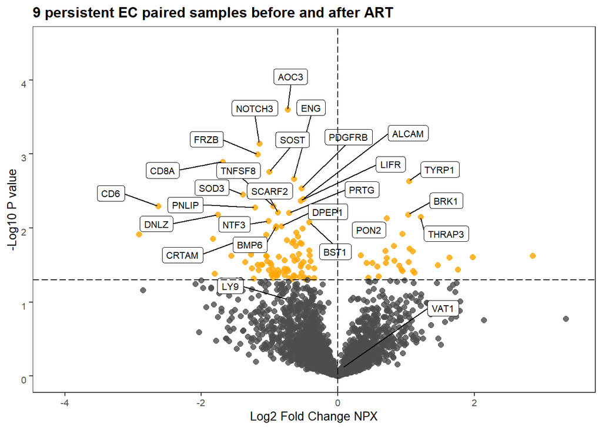

```r
# make the volcano plot
options(ggrepel.max.overlaps = Inf)
g <- ggplot(diff_df, aes(x=LOG_FC, y=-log10(RAW_P))) +
  geom_point(aes(color=group), alpha=0.8, size=2) +
  scale_color_manual(values=c("orange","#4d4d4d")) + # no red because no FDR significant
  theme_bw() + # size of plotting window
  theme(legend.background=element_rect(),
        plot.title=element_text(angle=0, size=12, face="bold", vjust=1),
        panel.grid.major=element_blank(), #Remove gridlines
        panel.grid.minor=element_blank(), #Remove gridlines
        axis.text.x=element_text(angle=0, size=8, vjust=1),
        axis.text.y=element_text(angle=0, size=8, vjust=1),
        axis.title=element_text(size=10),
        legend.position = "none") +
  # guides(colour = guide_legend(override.aes=list(size=2.5))) + #  Change the size of the icons/symbols in the legend
  xlab("Log2 Fold Change NPX") +
  ylab("-Log10 P value") +
  ggtitle("9 persistent EC paired samples before and after ART" ) +
  geom_label_repel(  #Add the text labels
    label.size = .25, #Size of label border, in mm.
    box.padding = unit(0.45, "lines"),
    label.padding = 0.25, # Amount of padding around label, as unit or number.
    label.r = 0.15, #Radius of rounded corners,
    size = 2.75, aes(label = LABEL,hjust = .5))+
  xlim(-4.1,3.4) + ylim(0, 4.5) + # limits of the graph
  geom_vline(xintercept=c(0), linetype="longdash", colour="black", size=0.4) + # Add a vertical line for Estimate change cut-offs
  geom_hline(yintercept= -log10(0.05), linetype="longdash", colour="black", size=0.4) #Add a horizontal line for P-value cut-off
g
```

```r
ggsave(paste0(working_dir, "Outputs/ECVCART_Volcano_label_0.001RAWP_2FC_9EC_ART_2420_age_storage.pdf"), plot = g, device = NULL, path = NULL,scale = 1, width = 4, height =4, units = 'in', dpi = 300)
```

#### Suppl. Figure S3B - volcano VCpersistent over TIME

```r
# read the summary statistics for VC persistent over TIME
result2 <- openxlsx::read.xlsx(paste0(working_dir, "Outputs/Supplements_LMM_Olink_ECVC_ARTandTIME_2420_age_storage_sex_center.xlsx"), sheet = "VCpersistent_TIME_23")

diff_df <- result2[,c("Outcome","p-value","fdr","Value")]
colnames(diff_df) <- c("PROTEIN","RAW_P", "FDR_P","LOG_FC")

# add a grouping column for coloring by significance; default value is "not significant"
diff_df <- diff_df %>% mutate(group= case_when(FDR_P < 0.05 ~ "FDR Significant",
                                               RAW_P < 0.05 & FDR_P > 0.05 ~ "Nominal Significant",
                                               RAW_P > 0.05 ~ "NotSignificant"
                                               ))

# add a text label if 'FDR-P <0.05', or if 'FDR-P <0.05 but LOG_FC >2', or if CRTAM, LY9, CD6, VAT1.
for (i in 1:nrow(diff_df)){
  if(diff_df$RAW_P[i] < 0.01 | # 'FDR-P <0.05'
     (diff_df$FDR_P[i] < 0.05 & abs(diff_df$LOG_FC[i]) > 2 | # 'FDR-P <0.05 but LOG_FC >2'
     (diff_df$PROTEIN[i] %in% c("CRTAM","LY9","CD6","VAT1") # CRTAM, LY9, CD6, VAT1
     )))
  {diff_df$LABEL[i] <- diff_df$PROTEIN[i]} else
  {diff_df$LABEL[i] <- ""}}
diff_df
```

```
##                PROTEIN       RAW_P     FDR_P        LOG_FC               group
## 1                  LY9 0.004627176 0.9589763  2.953658e-01 Nominal Significant
## 2                 C1QA 0.004931734 0.9589763  2.021407e-01 Nominal Significant
## 3                POF1B 0.005855977 0.9589763 -4.035854e-01 Nominal Significant
## 4               INPP5J 0.007325013 0.9589763 -4.616064e-01 Nominal Significant
## 5                IFIT3 0.007331815 0.9589763  5.969718e-01 Nominal Significant
## 6                 ACE2 0.010881303 0.9589763 -3.244081e-01 Nominal Significant
## 7               SEMA6C 0.011293925 0.9589763 -2.952237e-01 Nominal Significant
## 8                KRT18 0.012031551 0.9589763 -7.839405e-01 Nominal Significant
## 9                  LHB 0.012751273 0.9589763  6.923538e-01 Nominal Significant
## 10            GTF2IRD1 0.013322274 0.9589763 -4.372692e-01 Nominal Significant
## 11             KIR3DL2 0.014126517 0.9589763  5.936742e-01 Nominal Significant
## 12               PLIN1 0.014588904 0.9589763 -3.290244e-01 Nominal Significant
## 13             NECTIN1 0.014922665 0.9589763 -2.804231e-01 Nominal Significant
## 14               GFOD2 0.014953660 0.9589763  7.631928e-01 Nominal Significant
## 15               IL5RA 0.015573468 0.9589763  3.050185e-01 Nominal Significant
## 16                PGM2 0.016041748 0.9589763  4.514719e-01 Nominal Significant
## 17               TIMP4 0.017428487 0.9589763  3.686661e-01 Nominal Significant
## 18                PRND 0.017913090 0.9589763 -4.885211e-01 Nominal Significant
## 19                APOB 0.018254463 0.9589763 -2.128426e-01 Nominal Significant
## 20               VEGFD 0.019088505 0.9589763  3.361154e-01 Nominal Significant
## 21              ADAM15 0.020369289 0.9589763 -2.774749e-01 Nominal Significant
## 22                CCN3 0.020749806 0.9589763 -3.372715e-01 Nominal Significant
## 23               TCTN3 0.021397067 0.9589763 -2.862291e-01 Nominal Significant
## 24                  TF 0.021875094 0.9589763 -2.342714e-01 Nominal Significant
## 25               RIPK4 0.022572333 0.9589763 -5.257215e-01 Nominal Significant
## 26               NELL1 0.023379597 0.9589763  3.175865e-01 Nominal Significant
## 27                AGR2 0.023825757 0.9589763 -9.187053e-01 Nominal Significant
## 28               UNC5D 0.027446874 0.9589763 -2.569410e-01 Nominal Significant
## 29           ADCYAP1R1 0.029637240 0.9589763  1.605582e-01 Nominal Significant
## 30               LMNB2 0.030174694 0.9589763 -2.016296e-01 Nominal Significant
## 31               CHAC2 0.030573372 0.9589763  4.323232e-01 Nominal Significant
## 32              HS6ST2 0.031612895 0.9589763 -3.544009e-01 Nominal Significant
## 33              VSTM2L 0.032343624 0.9589763 -3.779021e-01 Nominal Significant
## 34                 CRH 0.032627010 0.9589763  4.327314e-01 Nominal Significant
## 35              SLAMF7 0.032752481 0.9589763  3.246542e-01 Nominal Significant
## 36                STX6 0.033759983 0.9589763  4.961005e-01 Nominal Significant
## 37                VMO1 0.036452972 0.9589763  3.856703e-01 Nominal Significant
## 38               NUDT2 0.036826608 0.9589763  5.093567e-01 Nominal Significant
## 39           C1GALT1C1 0.037066315 0.9589763 -3.030604e-01 Nominal Significant
```

[output cut: 4787 more lines]

[output not shown]

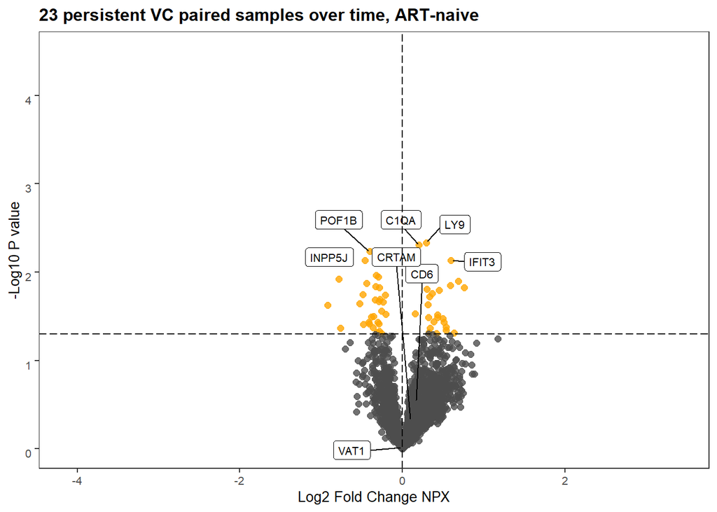

```r
# make the volcano plot
options(ggrepel.max.overlaps = Inf)
g <- ggplot(diff_df, aes(x=LOG_FC, y=-log10(RAW_P))) +
  geom_point(aes(color=group), alpha=0.8, size=2) +
  scale_color_manual(values=c("orange","#4d4d4d")) + # no red because no FDR significant
  theme_bw() + # size of plotting window
  theme(legend.background=element_rect(),
        plot.title=element_text(angle=0, size=12, face="bold", vjust=1),
        panel.grid.major=element_blank(), #Remove gridlines
        panel.grid.minor=element_blank(), #Remove gridlines
        axis.text.x=element_text(angle=0, size=8, vjust=1),
        axis.text.y=element_text(angle=0, size=8, vjust=1),
        axis.title=element_text(size=10),
        legend.position = "none") +
  # guides(colour = guide_legend(override.aes=list(size=2.5))) + #  Change the size of the icons/symbols in the legend
  xlab("Log2 Fold Change NPX") +
  ylab("-Log10 P value") +
  ggtitle("23 persistent VC paired samples over time, ART-naive" ) +
  geom_label_repel(  #Add the text labels
    label.size = .25, #Size of label border, in mm.
    box.padding = unit(0.45, "lines"),
    label.padding = 0.25, # Amount of padding around label, as unit or number.
    label.r = 0.15, #Radius of rounded corners,
    size = 2.75, aes(label = LABEL,hjust = .5))+
  xlim(-4.1,3.4) + ylim(0, 4.5) + # limits of the graph
  geom_vline(xintercept=c(0), linetype="longdash", colour="black", size=0.4) + # Add a vertical line for Estimate change cut-offs
  geom_hline(yintercept= -log10(0.05), linetype="longdash", colour="black", size=0.4) #Add a horizontal line for P-value cut-off
g
```

```r
ggsave(paste0(working_dir, "Outputs/Supplements_ECVCART_Volcano_label_0.01RAWP_2FC_23VC_TIME_2420_age_storage.pdf"), plot = g, device = NULL, path = NULL,scale = 1, width = 4, height = 4, units = 'in', dpi = 300)
```

#### Suppl. Figure S3C - volcano ECpersistent over TIME

```r
# read the summary statistics for EC persistent
result2 <- openxlsx::read.xlsx(paste0(working_dir, "Outputs/Supplements_LMM_Olink_ECVC_ARTandTIME_2420_age_storage_sex_center.xlsx"), sheet = "EC_TIME_19")

diff_df <- result2[,c("Outcome","p-value","fdr","Value")]
colnames(diff_df) <- c("PROTEIN","RAW_P", "FDR_P","LOG_FC")

# add a grouping column for coloring by significance; default value is "not significant"
diff_df <- diff_df %>% mutate(group= case_when(FDR_P < 0.05 ~ "FDR Significant",
                                               RAW_P < 0.05 & FDR_P > 0.05 ~ "Nominal Significant",
                                               RAW_P > 0.05 ~ "NotSignificant"
                                               ))

# add a text label if 'RAW_P < 0.001', or if 'RAW_P <0.05 but LOG_FC >2', or if CRTAM, LY9, CD6, VAT1.
for (i in 1:nrow(diff_df)){
  if(diff_df$RAW_P[i] < 0.01 | #
     (diff_df$RAW_P[i] < 0.05 & abs(diff_df$LOG_FC[i]) > 2 | #
     (diff_df$PROTEIN[i] %in% c("CRTAM","LY9","CD6","VAT1") # CRTAM, LY9, CD6, VAT1
     )))
  {diff_df$LABEL[i] <- diff_df$PROTEIN[i]} else
  {diff_df$LABEL[i] <- ""}}
diff_df
```

```
##                PROTEIN        RAW_P     FDR_P        LOG_FC               group
## 1               VCPKMT 0.0005554253 0.7944677 -1.6960339027 Nominal Significant
## 2                 GNLY 0.0040528353 0.7944677 -1.7987276801 Nominal Significant
## 3                FUCA1 0.0067350302 0.7944677 -0.7623432126 Nominal Significant
## 4               DUSP13 0.0068253628 0.7944677 -0.7980984379 Nominal Significant
## 5                 VWC2 0.0105728455 0.7944677  0.6011088527 Nominal Significant
## 6              S100A13 0.0112439186 0.7944677 -0.6850599925 Nominal Significant
## 7                 CTSL 0.0114276615 0.7944677 -0.4891527451 Nominal Significant
## 8                PCSK7 0.0127837923 0.7944677  0.5697900307 Nominal Significant
## 9                MFAP5 0.0152644847 0.7944677  0.7110371849 Nominal Significant
## 10               MFAP4 0.0163663370 0.7944677  0.4477961931 Nominal Significant
## 11                RRM2 0.0164472079 0.7944677 -0.9935430751 Nominal Significant
## 12              ADAM22 0.0166391828 0.7944677  0.6410123672 Nominal Significant
## 13               CDC27 0.0167558054 0.7944677 -1.3168323086 Nominal Significant
## 14               MEP1B 0.0169239815 0.7944677  1.2851790871 Nominal Significant
## 15               IFNL1 0.0187980071 0.7944677  0.8341366947 Nominal Significant
## 16                TPP1 0.0188794924 0.7944677 -0.6806628833 Nominal Significant
## 17               FARSA 0.0195453475 0.7944677 -1.2985311142 Nominal Significant
## 18                AKT3 0.0196081041 0.7944677 -0.9057466543 Nominal Significant
## 19                CTSS 0.0200492870 0.7944677 -0.3707414093 Nominal Significant
## 20              CRISP2 0.0218616998 0.7944677 -0.6936977445 Nominal Significant
## 21               FOXO3 0.0230761300 0.7944677 -1.8225466604 Nominal Significant
## 22                USP8 0.0240979355 0.7944677 -1.8568096197 Nominal Significant
## 23               CCL15 0.0241401105 0.7944677 -0.5608246470 Nominal Significant
## 24             CEACAM6 0.0243553927 0.7944677 -0.5083046948 Nominal Significant
## 25              DRAXIN 0.0246684129 0.7944677  0.5644859255 Nominal Significant
## 26                GOT1 0.0255360104 0.7944677 -0.7059570628 Nominal Significant
## 27                SIL1 0.0257903894 0.7944677  0.3256015722 Nominal Significant
## 28               EPHB6 0.0270895842 0.7944677  0.5064820061 Nominal Significant
## 29               IL17F 0.0273327865 0.7944677 -1.0375424122 Nominal Significant
## 30              CEP152 0.0274112559 0.7944677 -1.3809753543 Nominal Significant
## 31              SLAMF1 0.0276629424 0.7944677 -0.9953453325 Nominal Significant
## 32              MAN2B2 0.0276922099 0.7944677 -0.6277538965 Nominal Significant
## 33               MERTK 0.0298490845 0.7944677 -0.4010201675 Nominal Significant
## 34               MDGA1 0.0300707451 0.7944677  0.7485715159 Nominal Significant
## 35               LRRN1 0.0310765924 0.7944677  0.5643802891 Nominal Significant
## 36                SLA2 0.0311716796 0.7944677 -2.4370417998 Nominal Significant
## 37               C1QL2 0.0318661076 0.7944677 -0.5149637030 Nominal Significant
## 38             CLEC12A 0.0320427779 0.7944677 -0.5019038318 Nominal Significant
## 39                ARSB 0.0329593793 0.7944677 -0.8710644562 Nominal Significant
```

[output cut: 4787 more lines]

[output not shown]

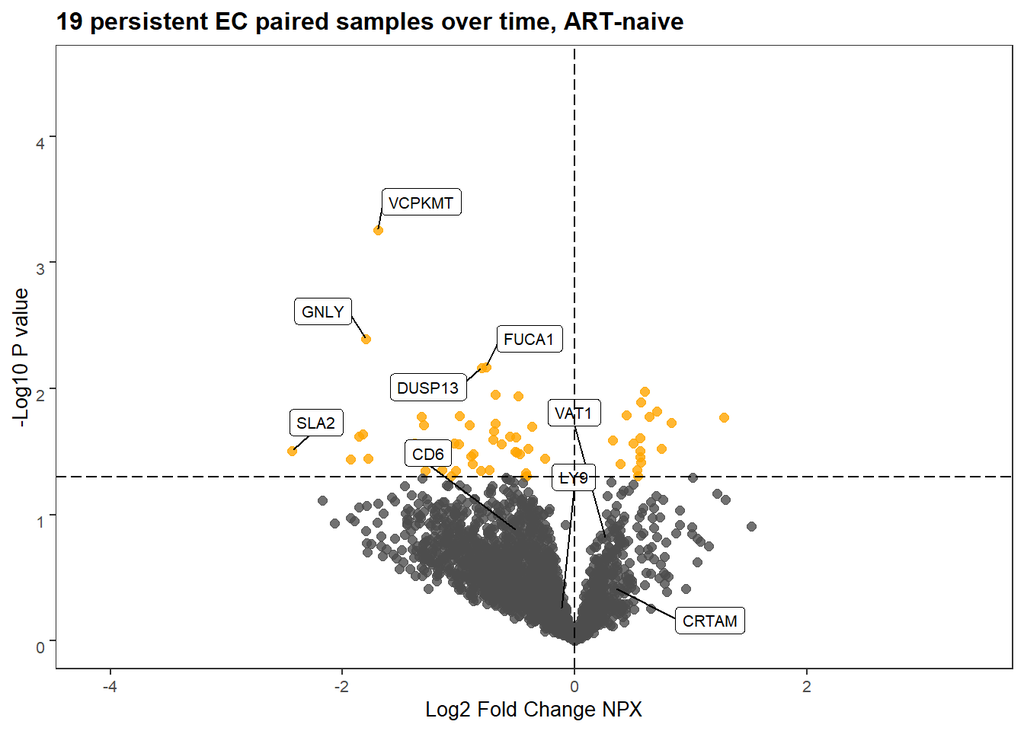

```r
# make the volcano plot
options(ggrepel.max.overlaps = Inf)
g <- ggplot(diff_df, aes(x=LOG_FC, y=-log10(RAW_P))) +
  geom_point(aes(color=group), alpha=0.8, size=2) +
  scale_color_manual(values=c("orange","#4d4d4d")) + # no red because no FDR significant
  theme_bw() + # size of plotting window
  theme(legend.background=element_rect(),
        plot.title=element_text(angle=0, size=12, face="bold", vjust=1),
        panel.grid.major=element_blank(), #Remove gridlines
        panel.grid.minor=element_blank(), #Remove gridlines
        axis.text.x=element_text(angle=0, size=8, vjust=1),
        axis.text.y=element_text(angle=0, size=8, vjust=1),
        axis.title=element_text(size=10),
        legend.position = "none") +
  # guides(colour = guide_legend(override.aes=list(size=2.5))) + #  Change the size of the icons/symbols in the legend
  xlab("Log2 Fold Change NPX") +
  ylab("-Log10 P value") +
  ggtitle("19 persistent EC paired samples over time, ART-naive" ) +
  geom_label_repel(  #Add the text labels
    label.size = .25, #Size of label border, in mm.
    box.padding = unit(0.45, "lines"),
    label.padding = 0.25, # Amount of padding around label, as unit or number.
    label.r = 0.15, #Radius of rounded corners,
    size = 2.75, aes(label = LABEL,hjust = .5))+
  xlim(-4.1,3.4) + ylim(0, 4.5) + # limits of the graph
  geom_vline(xintercept=c(0), linetype="longdash", colour="black", size=0.4) + # Add a vertical line for Estimate change cut-offs
  geom_hline(yintercept= -log10(0.05), linetype="longdash", colour="black", size=0.4) #Add a horizontal line for P-value cut-off
g
```

```r
ggsave(paste0(working_dir, "Outputs/Supplements_ECVCART_Volcano_label_0.01RAWP_2FC_19EC_TIME_2420_age_storage.pdf"), plot = g, device = NULL, path = NULL,scale = 1, width = 4, height =4, units = 'in', dpi = 300)
```

#### Figure 2E, pathway analysis of 101 downregulated proteins in VCpersistent after ART

**ADDENDUM 27-2-2024:**

We decided to show the cytoscape pathway network, of the 47 LMM FDR-significant downregulated proteins.

```r
pathways <- openxlsx::read.xlsx(paste0(working_dir, "Inputs/PATHWAY_LIMMA_Olink_ECVC_ARTandTIME_2420_age_storage.xlsx"), sheet = "GOBP_KEGG_REACTOME")

colnames(pathways)
```

```
##  [1] "Category"        "Term"            "Count"           "%"
##  [5] "PValue"          "Genes"           "List.Total"      "Pop.Hits"
##  [9] "Pop.Total"       "Fold.Enrichment" "Bonferroni"      "Benjamini"
## [13] "FDR"
```

```r
head(pathways)
```

```
##           Category
## 1 GOTERM_BP_DIRECT
## 2 GOTERM_BP_DIRECT
## 3 GOTERM_BP_DIRECT
## 4 GOTERM_BP_DIRECT
## 5 GOTERM_BP_DIRECT
## 6 GOTERM_BP_DIRECT
##                                                            Term Count        %
## 1            GO:0007166~cell surface receptor signaling pathway    24 23.76238
## 2                                    GO:0006955~immune response    22 21.78218
## 3        GO:0042102~positive regulation of T cell proliferation    11 10.89109
## 4                                  GO:0042110~T cell activation    10  9.90099
## 5                           GO:0002250~adaptive immune response    15 14.85149
## 6 GO:0032729~positive regulation of interferon-gamma production    10  9.90099
##         PValue
```

[output cut: 27 more lines]

```r
# Clean up pathway name
stringr::str_split_i(pathways$Term,"~",2)
```

```
##   [1] "cell surface receptor signaling pathway"
##   [2] "immune response"
##   [3] "positive regulation of T cell proliferation"
##   [4] "T cell activation"
##   [5] "adaptive immune response"
##   [6] "positive regulation of interferon-gamma production"
##   [7] "inflammatory response"
##   [8] "positive regulation of natural killer cell mediated cytotoxicity"
##   [9] "T cell costimulation"
##  [10] "positive regulation of T cell mediated cytotoxicity"
##  [11] "cell-cell signaling"
##  [12] "adenylate cyclase-activating G-protein coupled receptor signaling pathway"
##  [13] "regulation of immune response"
##  [14] "positive regulation of NIK/NF-kappaB signaling"
##  [15] "cellular response to lipopolysaccharide"
```

[output cut: 102 more lines]

```r
which(pathways$Category =="GOTERM_BP_DIRECT" |
      pathways$Category == "REACTOME_PATHWAY")
```

```
##  [1]   1   2   3   4   5   6   7   8   9  10  11  12  13  14  15  16  17  18  19
## [20]  20  21  22  23  24  25  26  27  28  29  30  31  32  33  34  35  36  37  38
## [39]  39  40  41  42  43  44  45  46  47  48  49  50  51  52  53  54  55  56  57
## [58]  58  59  60  61  62  63  64  65  66  67  68  69  70  71  94  95  96  97  98
## [77]  99 100 101 102 103 104 105 106 107 108 109 110 111 112 113 114 115 116 117
```

```r
pathways <- pathways %>% mutate(NAME = case_when(Category =="GOTERM_BP_DIRECT" | Category == "REACTOME_PATHWAY" ~
                                       stringr::str_split_i(Term,"~",2),
                                     Category =="KEGG_PATHWAY" ~ stringr::str_split_i(Term,":",2)))

stringr::str_split_i(pathways$Term,":",2)
```

```
##   [1] "0007166~cell surface receptor signaling pathway"
##   [2] "0006955~immune response"
##   [3] "0042102~positive regulation of T cell proliferation"
##   [4] "0042110~T cell activation"
##   [5] "0002250~adaptive immune response"
##   [6] "0032729~positive regulation of interferon-gamma production"
##   [7] "0006954~inflammatory response"
##   [8] "0045954~positive regulation of natural killer cell mediated cytotoxicity"
##   [9] "0031295~T cell costimulation"
##  [10] "0001916~positive regulation of T cell mediated cytotoxicity"
##  [11] "0007267~cell-cell signaling"
##  [12] "0007189~adenylate cyclase-activating G-protein coupled receptor signaling pathway"
##  [13] "0050776~regulation of immune response"
##  [14] "1901224~positive regulation of NIK/NF-kappaB signaling"
##  [15] "0071222~cellular response to lipopolysaccharide"
```

[output cut: 102 more lines]

```r
which(pathways$Category == "KEGG_PATHWAY")
```

```
##  [1] 72 73 74 75 76 77 78 79 80 81 82 83 84 85 86 87 88 89 90 91 92 93
```

```r
#
pathways$NAME <- paste0(pathways$Category, ": ", pathways$NAME)
pathways <- pathways[order(pathways$FDR),]
pathways <- pathways[c(1:10),]


colnames(pathways)
```

```
##  [1] "Category"        "Term"            "Count"           "%"
##  [5] "PValue"          "Genes"           "List.Total"      "Pop.Hits"
##  [9] "Pop.Total"       "Fold.Enrichment" "Bonferroni"      "Benjamini"
## [13] "FDR"             "NAME"
```

[figure not shown]

```r
#####
library(RColorBrewer)

levels_orders <- pathways$NAME

pathways$NAME <- factor(pathways$NAME, levels = levels_orders)
pathways$minlog10FDR <- -log10(pathways$FDR)

ggplot(data = pathways, aes(x = rev(NAME), y = Fold.Enrichment, fill = minlog10FDR)) +
  geom_bar(stat = "identity") +
  theme_bw() + xlab("") + ylab("Fold Enrichment ") +
  theme(axis.text.y = element_text(color = "black", size = 10),
        axis.text.x = element_text(color = "black", size = 8),
        axis.title = element_text(color = "black", size = 10),
        legend.text = element_text(color = "black", size = 8),
        legend.title = element_text(color = "black", size = 10),
        legend.position = 'right') +
  coord_flip() + scale_fill_gradientn(colors = c("#74A9CF","#3690C0","#0570B0","#045A8D","#023858"))
```

```r
ggsave(paste0(working_dir, "Outputs/Supplements_PATHWAY_barplot_VCpersistent_ART_DOWN.pdf"), width = 9, height = 2.75, units = "in", dpi = 300)
```

#### Suppl. Figure S3A - PCA plots

We need several PC plots: pre and post ART (all participants), ART duration category (all participants), INSTI_yesno, NNRTI_yesno, PI_yesno.

Since we identify the need for correcting our data, it is more meaningful to plot the PC1 and PC2 of the residuals, since the point of the figure is to show whether there are differences by ART and ART duration and regimes.

We can make one PCA of all paired pre/post ART samples.To the metadata we need to add ART duration and ART regime.

```r
merge_df <- readRDS(paste0(working_dir, "Inputs/AthenaOlink_Time_ART_Paired_Cleaned.rds"))
summary(as.factor(merge_df$ART))
```

```
##   0   1
##  84 206
```

```r
summary(as.factor(merge_df$GROUP3))
```

```
##           EC_ARTnaiveT1           EC_ARTnaiveT2               EC_preART
##                      19                      19                       9
##                EC_onART VCpersistent_ARTnaiveT1 VCpersistent_ARTnaiveT2
##                       9                      23                      23
##     VCpersistent_preART      VCpersistent_onART      VCtransient_preART
##                      57                      57                      36
##       VCtransient_onART                    NA's
##                      36                       2
```

```r
dfart <- droplevels(merge_df[which(merge_df$ART == 1),])
# remove the N=2 with loss status unknown
dfart <- dfart[-which(is.na(dfart$GROUP3)),]
summary(as.factor(dfart$GROUP3))
```

```
##           EC_preART            EC_onART VCpersistent_preART  VCpersistent_onART
##                   9                   9                  57                  57
##  VCtransient_preART   VCtransient_onART
##                  36                  36
```

```r
summary(as.factor(dfart$Timepoint)) # pre and post ART
```

```
##  T1  T2
## 102 102
```

```r
npxart <- dfart[,c(grep("GP2", colnames(dfart)):grep("NFU1", colnames(dfart)))]

# add categorical ART duration
dfart <- dfart %>% mutate(ART_DUR_cat = case_when(T2_ART_DUR_DAYS < 365 ~ "<1year",
                                 T2_ART_DUR_DAYS >= 365 & T2_ART_DUR_DAYS < 1825 ~ "1-5years",
                                 T2_ART_DUR_DAYS >= 1825 & T2_ART_DUR_DAYS < 3650 ~ "5-10years",
                                 T2_ART_DUR_DAYS >= 3650 ~ ">=10years"))
dfart$ART_DUR_cat <- factor(dfart$ART_DUR_cat, levels = c("<1year","1-5years","5-10years",">=10years"))

# extract residuals after correcting for AGE, and STORAGE_TIME with LIMMA
# Generate the protein expression matrix
eset <- as.matrix(t(npxart))  # Transpose data
dim(eset) # [1] 2420  183
```

```
## [1] 2420  204
```

```r
# Design matrix
design_cov <- model.matrix(~ 0 + AGE + STORAGE_TIME, data = dfart)
#Fitting model
fit1_cov <- lmFit(eset, design_cov) # limma assumes log-transformed data, which the NPX values already are
# Limma residuals matrix
ResidualsMatrix <- residuals(fit1_cov, eset)

# store residuals in new dataframe for S2D
npx_s3a <- data.frame(t(ResidualsMatrix))
sum(rownames(dfart) == rownames(npx_s3a))
```

```
## [1] 204
```

```r
prin_comp <- prcomp(npx_s3a, center = T,scale. = T) # In Nadira's script, it was  `scale. = False`, although in the PC regressions and in Vicky's example script, we set scale.unit in PCA() always to True. Here I also set `scale. = T`.
summary(prin_comp)$importance[2,c(1:5)]
```

```
##     PC1     PC2     PC3     PC4     PC5
## 0.23611 0.08211 0.03756 0.03585 0.02474
```

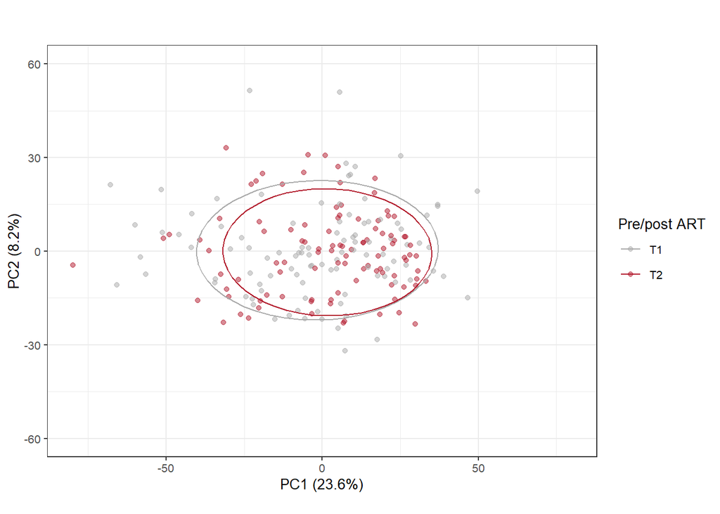

```r
# PCA Plot
 ggbiplot(prin_comp, obs.scale = 1, var.scale = 1,
              #labels = rownames(prin_comp$x),
              groups = as.factor(dfart$Timepoint),
              circle = F, ellipse = T, var.axes = F,
              alpha = 0.5,ellipse.fill = "none",ellipse.linewidth = 0.5)+
  #geom_point(shape=as.factor(df_m_1$NONVIREMIC),
  #           aes(colour=as.factor(master_df$VL_cat)),
  #           alpha = .5,
  #           size=1.5)+
  scale_color_manual(values = c("darkgrey","#b2182b"),name = "Pre/post ART") +
  theme(legend.direction = 'horizontal',
        legend.position = 'top')+
  theme_bw(base_size=10)+
  labs(title ="") + ylim(-60,60) + xlim(-80,80)
```

```r
ggsave(paste0(working_dir,"Outputs/Supplements_FigureS3A_PCAresiduals_plot_ART_102_102samp_2420proteins.pdf"), dpi = 300, width = 11.25, height = 10, units = "cm" )

## statistics:

############
### PCA Plot ART types
# subset only the T2 samples
dim(npx_s3a)
```

```
## [1]  204 2420
```

```r
npx_s3_artonly <- npx_s3a[-which(is.na(dfart$T2_ART_DUR_DAYS)),]
dfart_artonly <- dfart[-which(is.na(dfart$T2_ART_DUR_DAYS)),]
sum(rownames(dfart_artonly) == rownames(npx_s3_artonly))
```

```
## [1] 102
```

```r
prin_comp2 <- prcomp(npx_s3_artonly, center = T,scale. = T) # In Nadira's script, it was  `scale. = False`, although in the PC regressions and in Vicky's example script, we set scale.unit in PCA() always to True. Here I also set `scale. = T`.
summary(prin_comp2)$importance[2,c(1:5)]
```

```
##     PC1     PC2     PC3     PC4     PC5
## 0.23621 0.08119 0.04829 0.03237 0.03023
```

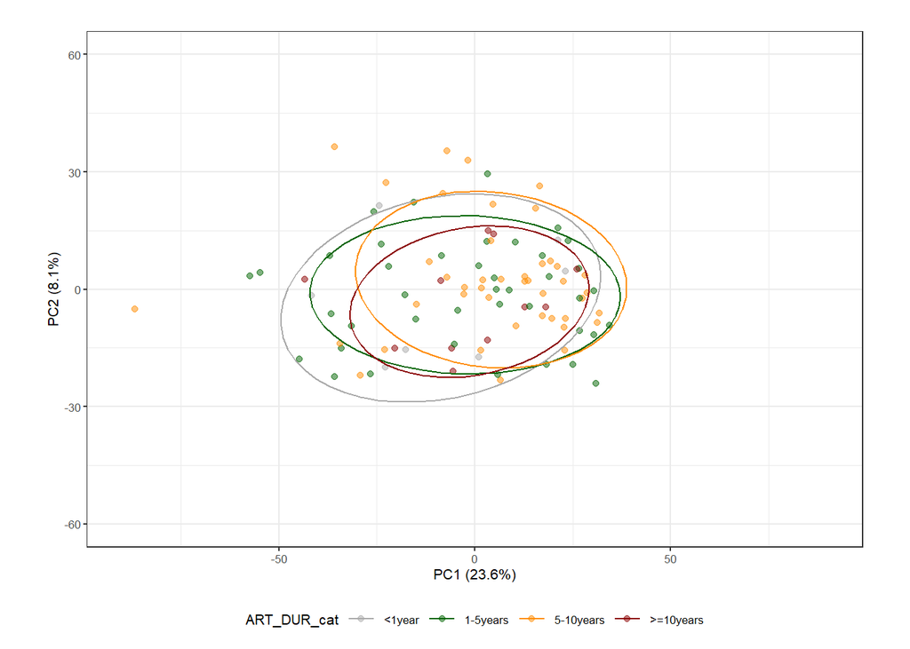

```r
# define function for PCA plot
f_pca_art <- function(variable) {
g <- ggbiplot(prin_comp2, obs.scale = 1, var.scale = 1,
              groups = as.factor(dfart_artonly[,variable]),
              circle = F, ellipse = T, var.axes = F,
              alpha = 0.5,ellipse.fill = "none",ellipse.linewidth = 0.5)+
  scale_color_manual(values = c("darkgrey","darkgreen","darkorange","darkred"),name = variable) +
  theme_bw(base_size=8)+
  theme(legend.direction = 'horizontal',
        legend.position = "bottom")+
  labs(title ="") + ylim(-60,60) + xlim(-90,90)
print(g)
  ggsave(paste0(working_dir, "Outputs/Supplements_FigureS3A_PCAresiduals_plot_",variable,"_102samp_2420proteins.pdf"), g, dpi = 300, width = 6, height = 6, units = "cm" )
}

f_pca_art("ART_DUR_cat")
```

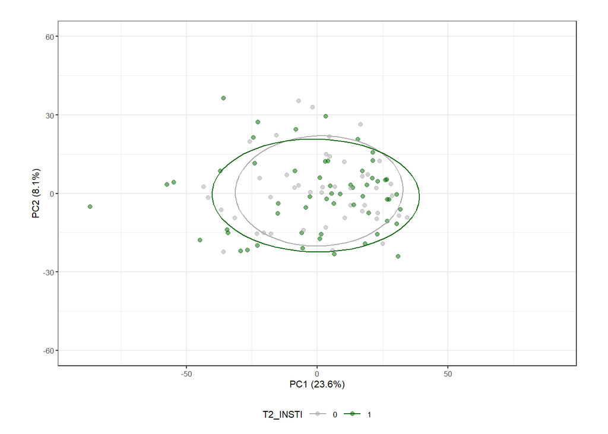

```r
f_pca_art("T2_INSTI")
```

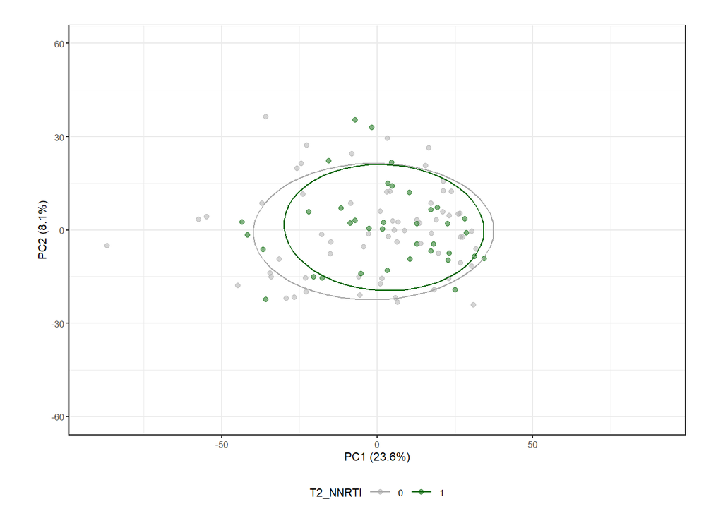

```r
f_pca_art("T2_NNRTI")
```

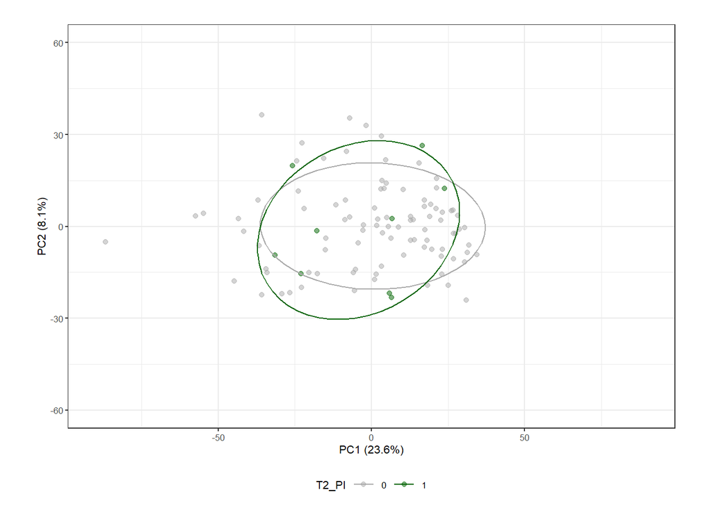

```r
f_pca_art("T2_PI")
```

##### Calculate P values for shift in PC1 and PC2 pre/post ART

Since I use here the pca of the residuals, the P values are different. In fact, they are no longer significant, suggesting that the effect of ART is very specific on these 100 or so proteins that are downregulated, that have to do mainly with T cell activation and turnover.

Note that the code below is Nadira’s, and can also be used to display density plots on the axes of the PC plot.

```r
#### STATISTICS PC1 and PC2 Pvalue pre-post ART (204 paired samples of 102 individuals)
library(plyr)
library(rstatix)
library(ggpubr)
data_pca <- as.data.frame(prin_comp$x[,1:4])
data_pca$Cohort <- dfart$Timepoint

makeStars <- function(x){
  stars <- c( "***", "**", "*", "ns")
  vec <- c(0, 0.0005, 0.005, 0.05, 1)
  i <- findInterval(x, vec)
  stars[i]
}

mu <- ddply(data_pca, "Cohort", summarise, grp.mean=mean(PC1))
stat.test_1 <- data_pca %>% wilcox_test(PC1 ~ Cohort)
stat.test_1 <- stat.test_1 %>% add_xy_position(fun = "mean_sd", x = "Cohort") %>%
  mutate(signif = makeStars(p))

mu_2 <- ddply(data_pca, "Cohort", summarise, grp.mean=mean(PC2))
stat.test_2 <- data_pca %>% wilcox_test(PC2 ~ Cohort)
stat.test_2 <- stat.test_2 %>% add_xy_position(fun = "mean_sd", x = "Cohort")%>%
  mutate(signif = makeStars(p))

rbind(stat.test_1, stat.test_2)
```

```
## # A tibble: 2 × 12
##   .y.   group1 group2    n1    n2 statistic     p y.position groups   xmin  xmax
##   <chr> <chr>  <chr>  <int> <int>     <dbl> <dbl>      <dbl> <named> <dbl> <dbl>
## 1 PC1   T1     T2       102   102      4813 0.357       24.0 <chr>       1     2
## 2 PC2   T1     T2       102   102      5269 0.875       15.3 <chr>       1     2
## # ℹ 1 more variable: signif <chr>
```